# NMF Final (Diurnal))

William Zhang, Eva, Jerry, Meredith

2025-03-21

```r
# load the packages
library(NMF)
library(tidyverse)
library(grid)
library(gridExtra)
library(readxl)
library(circular)
library(lwgeom)
library(units)
```

# Procedure

1. Remove hourly observation with missing observation for any chemical
2. Remove background noise level using min values (except for chemicals with minimum value < 2*LOD and maximum value > 100*LOD)
3. Zero values are converted to a random value between 0 and 0.5*LOD
4. Normalize using min and max
5. Remove Ozone (wouldn’t affect # of obs.)

## Reading the data

```r
hourly_data <- readRDS("../DataProcessing/Trailer_hourly_merge_20240905.rds")
```

```r
# PROCEDURE STEP 1:
hourly_data_diurnal <- hourly_data %>% rename('co2' = 'co2_ppm') %>%
  mutate(datetime_mountain = with_tz(as.POSIXct(time_utc, tz = 'UTC',
                                                format = "%Y-%m-%d %H:%M:%OS"),
                                     tzone = "America/Denver")) %>%
  filter(date(datetime_mountain) >= '2023-05-01') %>%
  filter(hour(datetime_mountain) >= 11 & hour(datetime_mountain) <= 17)

vocs <- c("ethane", "ethene", "propane", "propene",
                                        "1_3-butadiene", "i-butane", "n-butane",
                                        "acetylene", "cyclopentane", "i-pentane",
                                        "n-pentane", "n-hexane", "isoprene", "n-heptane",
                                        "benzene", "n-octane", "toluene", "ethyl-benzene",
                                        "m&p-xylene", "o-xylene")


non_vocs <- c('ch4', 'co2', 'co', 'h2s', 'so2', 'nox', 'o3')

# remove row with missing obs for any chemical
hourly_nona_diurnal <- hourly_data_diurnal %>%
  select(any_of(c('day', 'time_utc', vocs, non_vocs, 'wdr_deg', 'wsp_ms'))) %>%
  na.omit()

# retrieving the vocs, removing everything else except the vocs
hourly_vocs_diurnal <- hourly_nona_diurnal %>% select(any_of(vocs))

# retrieving the non-vocs: co2_ppm, nox, ch4, h2s, so2, o3
# double check this
hourly_non_vocs_diurnal <- hourly_nona_diurnal %>% select(any_of(non_vocs))

hourly_full_nona_diurnal <- cbind(hourly_non_vocs_diurnal, hourly_vocs_diurnal)

# retrive a vector of yearmonth
hourly_dates_diurnal <- hourly_nona_diurnal %>%
  mutate(yearmonth = substring(day, 0, 7)) %>%
  pull(yearmonth)
```

## Data visualisation

- Boxplots of the hourly concentrations non-voc

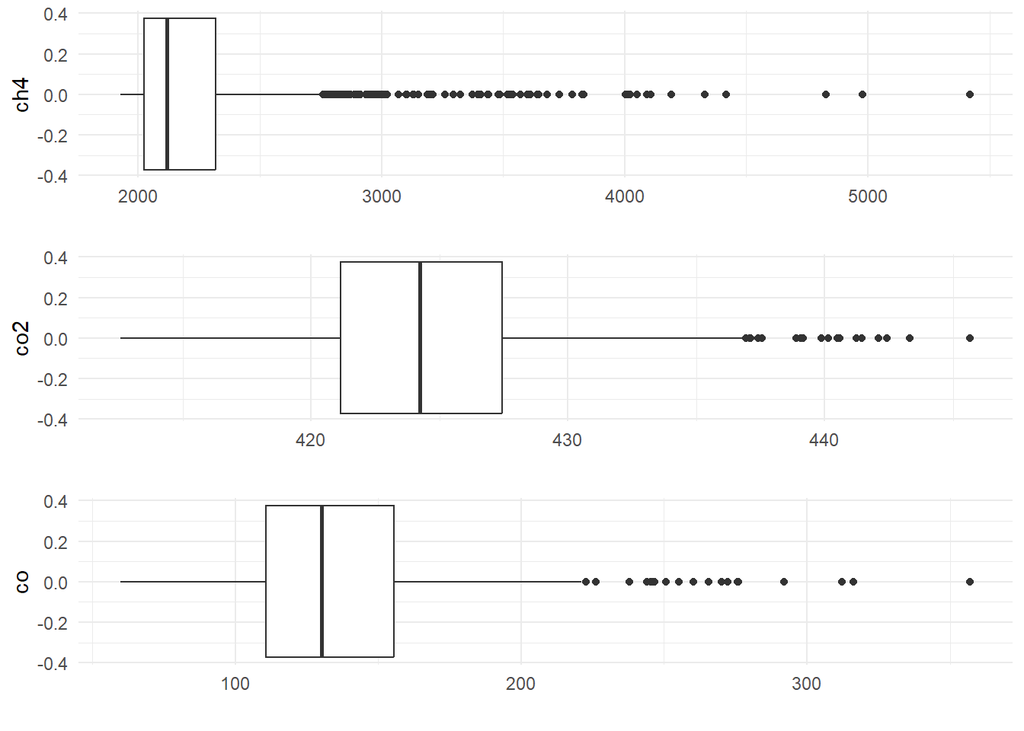

- Boxplots sulfur compounds, NOx, ozone

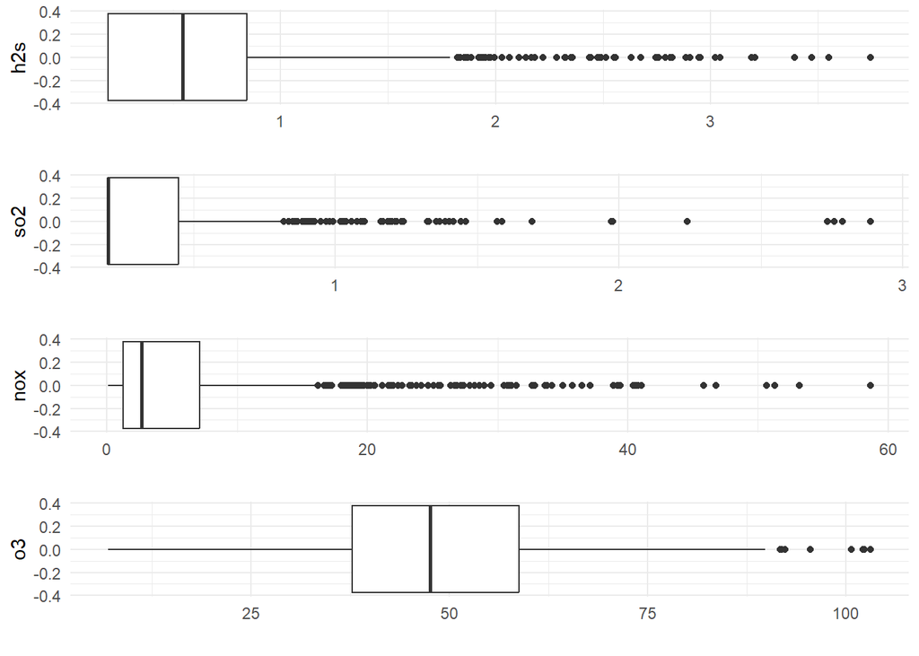

- Boxplots VOCs

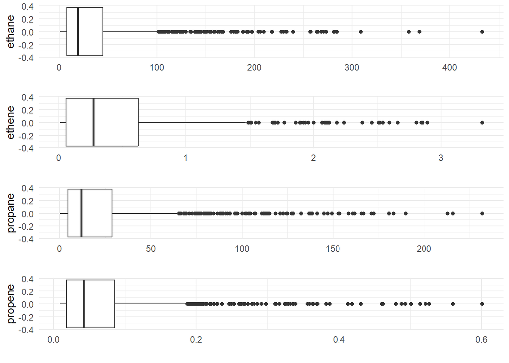

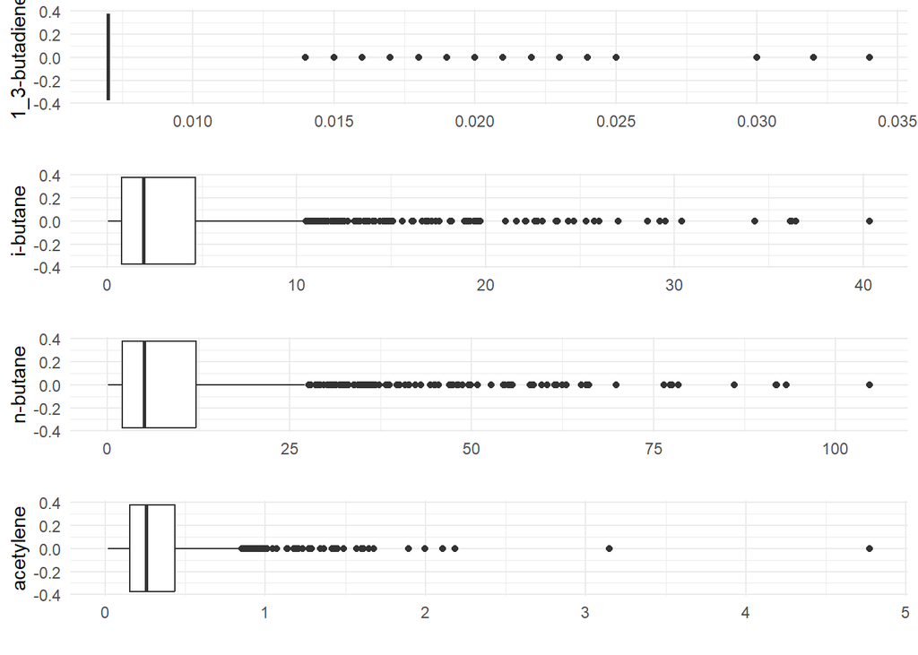

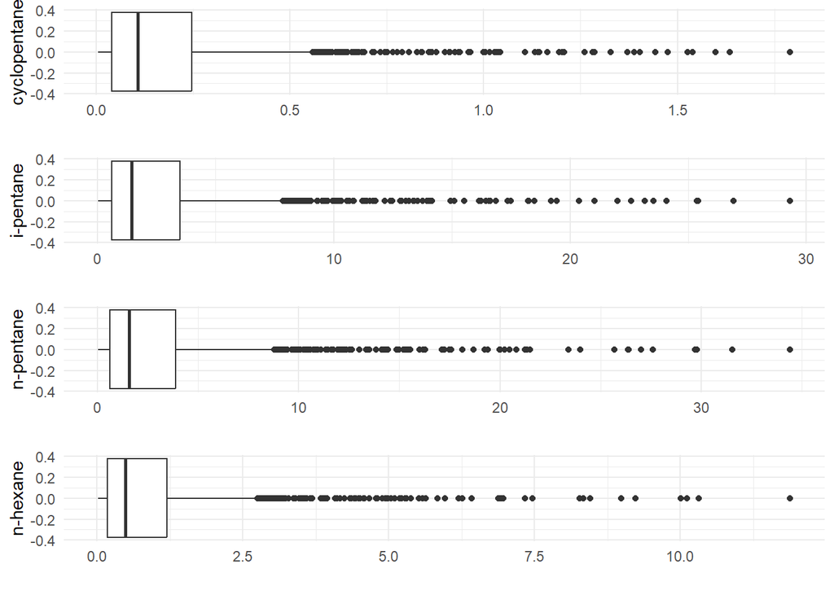

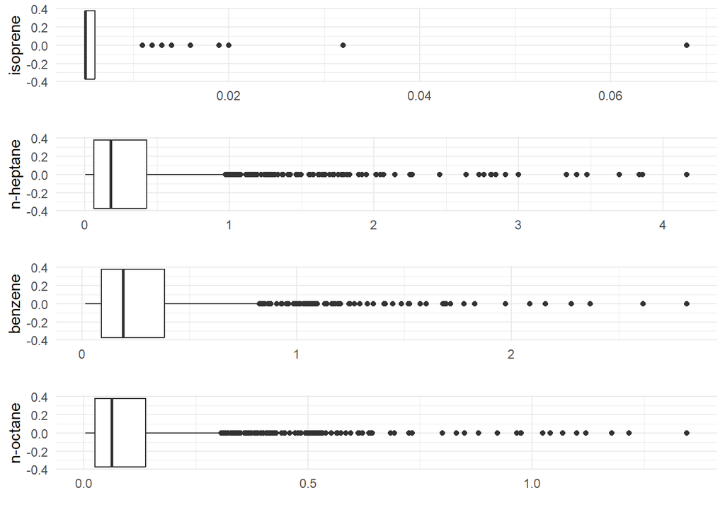

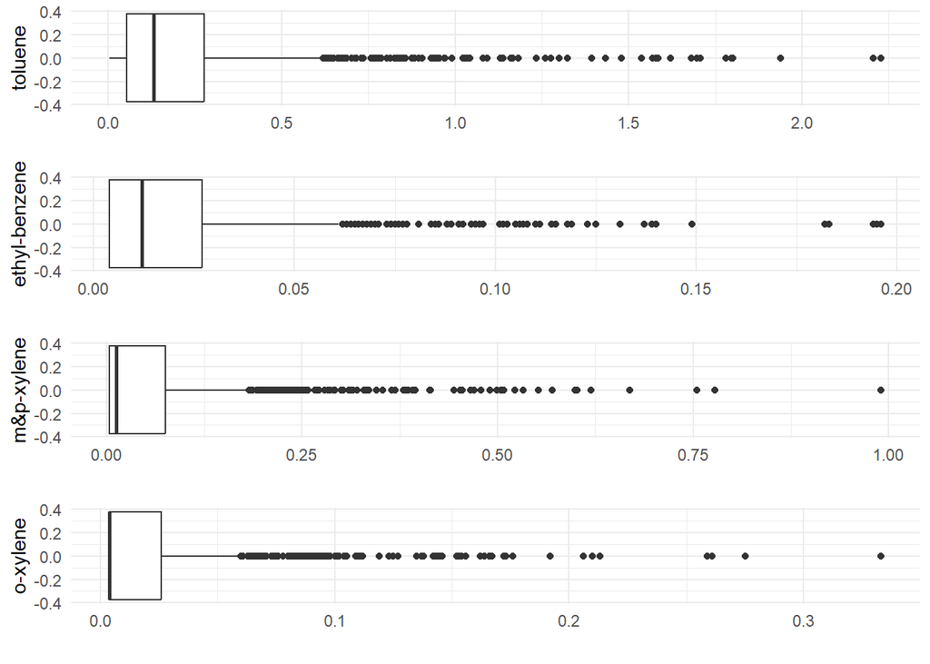

### Data pre-processing

#### Step 1: limits of detection

- STEP 1: Limits of detection

```r
# Define LOD for each chemical
LOD_non_voc <- c('ch4' = 0.9,
             'co2' = 0.0433,
             'co' = 20,
             'h2s' = 0.4,
             'so2' = 0.4,
             'nox' = 0.05,
             'o3' = 1)

# LOD_voc_monthly <- read_csv('../data/LNM_VOC_LOD_Rounded.csv') %>% select(-1)
#
# # extract the yearmonth from date variables
# LOD_voc_monthly <- LOD_voc_monthly %>%
#   mutate(yearmonth = strftime(as.POSIXct(start_date, format = '%Y-%m-%d %H:%M:%S',
#                                             tz = 'UTC'), '%Y-%m'))
#
# LOD_voc_monthly <- LOD_voc_monthly %>%
#   select(-c(start_date, end_date)) %>%
#   select(!any_of(ends_with('half_ldl')))
#
# colnames(LOD_voc_monthly) <- str_replace_all(names(LOD_voc_monthly), '_ldl', '')

LOD_voc_avg <- read_xlsx('../data/LNM_VOC_Uncertainties.xlsx', skip = 1)
LOD_voc_avg <- LOD_voc_avg %>%
  select(1, 4) %>%
  rename('LOD' = 2, 'chemical' = 1) %>%
  head(20)
```

#### Step 2: Background correction

- STEP 2: Background correction

```
##           ch4           co2            co           h2s           so2
##      1928.000       412.590        59.910         0.200         0.200
##           nox            o3        ethane        ethene       propane
##         0.103         7.000         0.916         0.011         0.224
##       propene 1_3-butadiene      i-butane      n-butane     acetylene
##         0.009         0.007         0.035         0.090         0.019
##  cyclopentane     i-pentane     n-pentane      n-hexane      isoprene
##         0.005         0.038         0.042         0.021         0.005
##     n-heptane       benzene      n-octane       toluene ethyl-benzene
##         0.004         0.017         0.004         0.004         0.004
##    m&p-xylene      o-xylene
##         0.004         0.004
```

- Summary statistics of backgrounds and extremes

```r
get_info <- function(column) {
  N <- length(column)
  background <- quantile(column, 0)
  quantile1 <- quantile(column, 0.01)
  quantile99 <- quantile(column, 0.99)
  n_background <- sum(column == background)
  max <- max(column)
  return(c(N, quantile1, quantile99, max, background, n_background))
}

info_table <- hourly_full_nona_diurnal %>%
  reframe(across(everything(), ~ get_info(.x)))

info_table <- info_table %>%
  mutate(rownames = c('N', '1st percentile', '99th percentile', 'Max',
                      'Background', '# Background')) %>%
  pivot_longer(-rownames) %>%
  pivot_wider(names_from = rownames, values_from = value)

knitr::kable(info_table)
```

| name | N | 1st percentile | 99th percentile | Max | Background | # Background |
| --- | --- | --- | --- | --- | --- | --- |
| ch4 | 1136 | 1937.40500 | 3943.36000 | 5420.000 | 1928.000 | 1 |
| co2 | 1136 | 415.27750 | 439.62150 | 445.660 | 412.590 | 1 |
| co | 1136 | 76.16800 | 253.65900 | 357.100 | 59.910 | 1 |
| h2s | 1136 | 0.20000 | 2.86360 | 3.744 | 0.200 | 336 |
| so2 | 1136 | 0.20000 | 1.43390 | 2.886 | 0.200 | 717 |
| nox | 1136 | 0.18340 | 39.39435 | 58.654 | 0.103 | 1 |
| o3 | 1136 | 14.63500 | 87.49500 | 103.100 | 7.000 | 1 |
| ethane | 1136 | 1.36270 | 261.46000 | 433.000 | 0.916 | 1 |
| ethene | 1136 | 0.01100 | 2.33130 | 3.321 | 0.011 | 78 |
| propane | 1136 | 0.58780 | 160.13000 | 231.800 | 0.224 | 1 |
| propene | 1136 | 0.00900 | 0.42680 | 0.601 | 0.009 | 230 |
| 1_3-butadiene | 1136 | 0.00700 | 0.02065 | 0.034 | 0.007 | 1090 |
| i-butane | 1136 | 0.09740 | 25.61950 | 40.340 | 0.035 | 1 |
| n-butane | 1136 | 0.23475 | 65.49950 | 104.700 | 0.090 | 1 |
| acetylene | 1136 | 0.04900 | 1.54030 | 4.773 | 0.019 | 2 |
| cyclopentane | 1136 | 0.00500 | 1.28460 | 1.791 | 0.005 | 56 |
| i-pentane | 1136 | 0.06900 | 19.35250 | 29.310 | 0.038 | 1 |
| n-pentane | 1136 | 0.07000 | 21.44050 | 34.420 | 0.042 | 1 |
| n-hexane | 1136 | 0.03000 | 6.96155 | 11.880 | 0.021 | 2 |
| isoprene | 1136 | 0.00500 | 0.01200 | 0.068 | 0.005 | 691 |
| n-heptane | 1136 | 0.01100 | 2.79250 | 4.164 | 0.004 | 3 |
| benzene | 1136 | 0.02400 | 1.68885 | 2.816 | 0.017 | 3 |
| n-octane | 1136 | 0.00400 | 0.90795 | 1.345 | 0.004 | 57 |
| toluene | 1136 | 0.00935 | 1.57615 | 2.228 | 0.004 | 7 |
| ethyl-benzene | 1136 | 0.00400 | 0.12300 | 0.196 | 0.004 | 419 |
| m&p-xylene | 1136 | 0.00400 | 0.50660 | 0.990 | 0.004 | 467 |
| o-xylene | 1136 | 0.00400 | 0.16665 | 0.333 | 0.004 | 612 |

- STEP 2 processing continued: background correction
- adjustments that were made according to paper: Gunnar’s paper section 2.2 and Guha 3.3
- Check whether chemical has background noise level that needs to be removed
- NO ADJUSTMENT if minimum value < 2xLOD and maximum value > 100xLOD

```r
adjusting_neg_bg_from_lod <- function(chemical, LOD, background, hourly_data_diurnal){
    # get min and max
    min_value <- min(hourly_data_diurnal[chemical], na.rm = TRUE)
    max_value <- max(hourly_data_diurnal[chemical], na.rm = TRUE)
    # if min less than double LOD or max > 100 times LOD
    # adjust to -100 (for entire column???)
    if (min_value < 2 * LOD & max_value > 100 * LOD ){
      return (0)
    }
  return (background)
}
```

- Check if background is negligible for non voc
- merge background and LOD

```r
background_lod_non_voc_diurnal <- tibble(chemical = non_vocs,
                                 LOD = LOD_non_voc,
                                 background = unname(background_levels[non_vocs]))
adjusted_background_non_voc_diurnal <- background_lod_non_voc_diurnal %>%
  rowwise() %>%
  mutate(min = min(hourly_full_nona_diurnal[chemical], na.rm = TRUE),
         LODx2 = 2 * LOD,
         criterion1 = min(hourly_full_nona_diurnal[chemical], na.rm = TRUE) < 2 * LOD,
         max = max(hourly_full_nona_diurnal[chemical], na.rm = TRUE),
         LODx100 = 100 * LOD,
         criterion2 = max(hourly_full_nona_diurnal[chemical], na.rm = TRUE) > 100 * LOD,
         adjusted_background = adjusting_neg_bg_from_lod(chemical, LOD, background,
                                                         hourly_full_nona_diurnal))
```

- Check if background is negligible for voc
- merge background and LOD

```r
background_lod_voc_diurnal <- LOD_voc_avg %>%
  left_join(tibble(chemical = setdiff(names(background_levels), non_vocs),
                   background = background_levels[setdiff(names(background_levels),
                                                          non_vocs)]))
adjusted_background_voc_diurnal <- background_lod_voc_diurnal %>%
  rowwise() %>%
  mutate(min = min(hourly_full_nona_diurnal[chemical], na.rm = TRUE),
         LODx2 = 2 * LOD,
         criterion1 = min(hourly_full_nona_diurnal[chemical], na.rm = TRUE) < 2 * LOD,
         max = max(hourly_full_nona_diurnal[chemical], na.rm = TRUE),
         LODx100 = 100 * LOD,
         criterion2 = max(hourly_full_nona_diurnal[chemical], na.rm = TRUE) > 100 * LOD,
         adjusted_background = adjusting_neg_bg_from_lod(chemical, LOD, background,
                                                         hourly_full_nona_diurnal))
```

- create dataset with background removed

```r
# So now we have the adjusted background concentrations
hourly_nona_bgrm_diurnal <- hourly_full_nona_diurnal %>%
  mutate(across(adjusted_background_non_voc_diurnal$chemical,
                ~  .x - adjusted_background_non_voc_diurnal$adjusted_background[
                    adjusted_background_non_voc_diurnal$chemical == cur_column()]))
hourly_nona_bgrm_diurnal <- hourly_nona_bgrm_diurnal %>%
  mutate(across(adjusted_background_voc_diurnal$chemical,
                ~  .x - adjusted_background_voc_diurnal$adjusted_background[
                    adjusted_background_voc_diurnal$chemical == cur_column()]))
```

- check number of 0 values per compound

```r
# look at zero values
colSums(hourly_nona_bgrm_diurnal == 0)
```

```
##           ch4           co2            co           h2s           so2
##             1             1             1           336           717
##           nox            o3        ethane        ethene       propane
##             1             1             1             0             1
##       propene 1_3-butadiene      i-butane      n-butane     acetylene
##           230          1090             1             1             0
##  cyclopentane     i-pentane     n-pentane      n-hexane      isoprene
##             0             1             1             2           691
##     n-heptane       benzene      n-octane       toluene ethyl-benzene
##             0             0             0             0           419
##    m&p-xylene      o-xylene
##             0           612
```

#### Step 3: Replace zero with random value between 0 and 0.5*LOD

- STEP 3: replace zero values with random values between 0 and 0.5xLOD

```r
set.seed(123)
replace_zero_with_random <- function(column, name, LOD_df){
  LOD <- LOD_df$LOD[LOD_df$chemical == name]
  column <- if_else(column == 0, round(runif(length(column), 0, 0.5 * LOD), 3), column)
  return (column)
}

hourly_nona_bgrm_zerorepl_diurnal <- hourly_nona_bgrm_diurnal %>%
  mutate(across(adjusted_background_non_voc_diurnal$chemical,
                ~ replace_zero_with_random(.x, cur_column(), adjusted_background_non_voc_diurnal)))

hourly_nona_bgrm_zerorepl_diurnal <- hourly_nona_bgrm_zerorepl_diurnal %>%
  mutate(across(adjusted_background_voc_diurnal$chemical,
                ~ replace_zero_with_random(.x, cur_column(), adjusted_background_voc_diurnal)))
```

#### Step 4: Normalize

- STEP 4: Normalize the measurements

```r
#normalizing function
normalize_column <- function(column){
  background <- quantile(column, 0)
  max <- quantile(column, 1) # this could be adjusted
  return ((column - background)/(max - background))
}
```

```r
# normalize all
hourly_nona_bgrm_zerorepl_norm_diurnal <- as_tibble(sapply(as.list(hourly_nona_bgrm_zerorepl_diurnal),
                                                   normalize_column))
#normalize the NON_VOC
summary(hourly_nona_bgrm_zerorepl_norm_diurnal)
```

```
##       ch4               co2               co              h2s
##  Min.   :0.00000   Min.   :0.0000   Min.   :0.0000   Min.   :0.00000
##  1st Qu.:0.02711   1st Qu.:0.2591   1st Qu.:0.1665   1st Qu.:0.04423
##  Median :0.05407   Median :0.3521   Median :0.2317   Median :0.09791
##  Mean   :0.09468   Mean   :0.3622   Mean   :0.2511   Mean   :0.14389
##  3rd Qu.:0.11159   3rd Qu.:0.4493   3rd Qu.:0.3178   3rd Qu.:0.18179
##  Max.   :1.00000   Max.   :1.0000   Max.   :1.0000   Max.   :1.00000
##       so2               nox                o3             ethane
##  Min.   :0.00000   Min.   :0.00000   Min.   :0.0000   Min.   :0.00000
##  1st Qu.:0.02792   1st Qu.:0.01913   1st Qu.:0.3202   1st Qu.:0.01572
##  Median :0.05417   Median :0.04316   Median :0.4219   Median :0.04180
##  Mean   :0.08302   Mean   :0.09679   Mean   :0.4308   Mean   :0.08611
##  3rd Qu.:0.09196   3rd Qu.:0.12017   3rd Qu.:0.5390   3rd Qu.:0.10222
##  Max.   :1.00000   Max.   :1.00000   Max.   :1.0000   Max.   :1.00000
##      ethene           propane           propene        1_3-butadiene
##  Min.   :0.00000   Min.   :0.00000   Min.   :0.00000   Min.   :0.00000
##  1st Qu.:0.01390   1st Qu.:0.01834   1st Qu.:0.01520   1st Qu.:0.07407
##  Median :0.07976   Median :0.04970   Median :0.05574   Median :0.11111
##  Mean   :0.12425   Mean   :0.10197   Mean   :0.10334   Mean   :0.14075
##  3rd Qu.:0.18520   3rd Qu.:0.12393   3rd Qu.:0.13007   3rd Qu.:0.18519
##  Max.   :1.00000   Max.   :1.00000   Max.   :1.00000   Max.   :1.00000
##     i-butane          n-butane         acetylene        cyclopentane
##  Min.   :0.00000   Min.   :0.00000   Min.   :0.00000   Min.   :0.00000
##  1st Qu.:0.01761   1st Qu.:0.01812   1st Qu.:0.02861   1st Qu.:0.01904
##  Median :0.04627   Median :0.04686   Median :0.05006   Median :0.05739
##  Mean   :0.09490   Mean   :0.09591   Mean   :0.06930   Mean   :0.10898
##  3rd Qu.:0.11430   3rd Qu.:0.11513   3rd Qu.:0.08729   3rd Qu.:0.13522
##  Max.   :1.00000   Max.   :1.00000   Max.   :1.00000   Max.   :1.00000
##    i-pentane         n-pentane          n-hexane          isoprene
##  Min.   :0.00000   Min.   :0.00000   Min.   :0.00000   Min.   :0.00000
##  1st Qu.:0.01971   1st Qu.:0.01663   1st Qu.:0.01297   1st Qu.:0.01587
##  Median :0.04822   Median :0.04448   Median :0.03943   Median :0.01587
##  Mean   :0.09761   Mean   :0.09298   Mean   :0.08363   Mean   :0.03651
##  3rd Qu.:0.11794   3rd Qu.:0.11148   3rd Qu.:0.09939   3rd Qu.:0.06349
##  Max.   :1.00000   Max.   :1.00000   Max.   :1.00000   Max.   :1.00000
##    n-heptane          benzene           n-octane          toluene
##  Min.   :0.00000   Min.   :0.00000   Min.   :0.00000   Min.   :0.00000
##  1st Qu.:0.01442   1st Qu.:0.02671   1st Qu.:0.01622   1st Qu.:0.02203
##  Median :0.04231   Median :0.06270   Median :0.04400   Median :0.05710
##  Mean   :0.08734   Mean   :0.10380   Mean   :0.08666   Mean   :0.10426
##  3rd Qu.:0.10156   3rd Qu.:0.13165   3rd Qu.:0.09993   3rd Qu.:0.12286
##  Max.   :1.00000   Max.   :1.00000   Max.   :1.00000   Max.   :1.00000
##  ethyl-benzene       m&p-xylene          o-xylene
##  Min.   :0.00000   Min.   :0.000000   Min.   :0.000000
##  1st Qu.:0.01042   1st Qu.:0.000000   1st Qu.:0.006079
##  Median :0.04167   Median :0.008621   Median :0.009118
##  Mean   :0.09419   Mean   :0.060146   Mean   :0.059988
##  3rd Qu.:0.11979   3rd Qu.:0.072008   3rd Qu.:0.066869
##  Max.   :1.00000   Max.   :1.000000   Max.   :1.000000
```

- FINAL step: create matrix of processed and normalized concentrations for NMF

```r
normalized_matrix <- as.matrix(hourly_nona_bgrm_zerorepl_norm_diurnal)
#important: using the normalized VOCs for this file
```

# NMF section

## Preprocess

### Global variables

```r
components <- 4:10
```

### Remove Ozone

```r
normalized_matrix_less_o3 <- normalized_matrix[ ,setdiff(colnames(normalized_matrix), "o3")]
```

### Compute error matrix

```r
# compute uncertainty matrix (inverse of weight?)
# Based on the Guha paper

uncertainty_matrix <- matrix(0, nrow = nrow(normalized_matrix_less_o3),
                        ncol = ncol(normalized_matrix_less_o3))
LOD_merged <- tibble(chemical = c(adjusted_background_non_voc_diurnal$chemical,
                                  adjusted_background_voc_diurnal$chemical),
                     LOD = c(adjusted_background_non_voc_diurnal$LOD,
                             adjusted_background_voc_diurnal$LOD))

LOD_merged <- tibble(chemical = names(hourly_nona_bgrm_zerorepl_norm_diurnal)) %>%
  left_join(LOD_merged) %>%
  filter(chemical %in% colnames(normalized_matrix_less_o3))
# creating uncertainty Matrix
for (i in 1:dim(uncertainty_matrix)[1]) {
  for (j in 1:dim(uncertainty_matrix)[2]) {
    chemical <- colnames(normalized_matrix_less_o3)[j]
    xij <- normalized_matrix_less_o3[i, j]
    LOD <- LOD_merged$LOD[LOD_merged$chemical == chemical]
    # Get LOD value for this row
    # Based on Guha Eq6, Eq5a, EQ5c
    # if (j == 1) {
    #   # based on equation 6, we sqrt ch4 (at column = 1) and times by 1
    #   uncertainty_matrix[i, j] <- sqrt(xij)
    # } else if (j == 2) {
    #   # 0.25 for co2
    #   uncertainty_matrix[i, j] <- 0.25 * sqrt(xij)
    # } else if (j == 3) {
    #   # 0.5 for CO
    #   uncertainty_matrix[i, j] <- 0.5 * sqrt(xij)
    # } else if (xij <= LOD) {
    #   uncertainty_matrix[i, j] <- 2 * LOD # equation 5a) in reference paper
    # } else {
    #   uncertainty_matrix[i, j] <- sqrt(((0.1 * xij)**2 + LOD**2))  #equation 5c) in reference paper
    # }

    # Based on Guha Eq5a, EQ5c
    if (xij <= LOD) {
      uncertainty_matrix[i, j] <- 2 * LOD # equation 5a) in reference paper
    } else {
      uncertainty_matrix[i, j] <- sqrt(((0.1 * xij)**2 + LOD**2))  #equation 5c) in reference paper
    }
  }
}
```

```r
# Convert zero uncertainties to the next smallest uncertainty of the corresponding compound
uncertainty_matrix[uncertainty_matrix==0]<-apply(uncertainty_matrix, 2, function(x) sort(x)[2])
# THIS NEEDS TO BE CHECKED IF WE WANT TO TAKE RECIPROCAL FOR EACH ELEMENT
# CURRENT RESULTS IS WHEN WEIGHT = UNCERTAINTY
# NOT POSSIBLE TO DO SIMPLY TAKE RECIPROCAL SINCE THERE'RE 0 UNCERTAINTIES
weight_matrix <- 1/uncertainty_matrix

summary(weight_matrix)
```

```
##        V1               V2               V3              V4
##  Min.   :0.5556   Min.   : 9.177   Min.   :0.025   Min.   :1.250
##  1st Qu.:0.5556   1st Qu.:15.954   1st Qu.:0.025   1st Qu.:1.250
##  Median :0.5556   Median :17.860   Median :0.025   Median :1.250
##  Mean   :0.5560   Mean   :17.756   Mean   :0.025   Mean   :1.331
##  3rd Qu.:0.5556   3rd Qu.:19.792   3rd Qu.:0.025   3rd Qu.:1.250
##  Max.   :1.1043   Max.   :22.904   Max.   :0.025   Max.   :2.487
##        V5              V6               V7               V8
##  Min.   :1.250   Min.   : 8.944   Min.   : 9.678   Min.   : 9.746
##  1st Qu.:1.250   1st Qu.:10.000   1st Qu.:19.231   1st Qu.:21.739
##  Median :1.250   Median :10.000   Median :32.583   Median :32.841
##  Mean   :1.273   Mean   :13.924   Mean   :29.133   Mean   :31.472
##  3rd Qu.:1.250   3rd Qu.:19.242   3rd Qu.:37.492   3rd Qu.:40.360
##  Max.   :2.486   Max.   :19.899   Max.   :38.268   Max.   :43.240
##        V9              V10              V11              V12
##  Min.   : 9.859   Min.   : 9.842   Min.   : 9.903   Min.   : 9.903
##  1st Qu.:29.412   1st Qu.:27.778   1st Qu.:38.074   1st Qu.:35.714
##  Median :48.490   Median :43.929   Median :49.060   Median :58.760
##  Mean   :43.784   Mean   :40.883   Mean   :50.032   Mean   :53.226
##  3rd Qu.:56.602   3rd Qu.:52.927   3rd Qu.:63.136   3rd Qu.:68.746
##  Max.   :58.530   Max.   :55.262   Max.   :69.053   Max.   :71.069
##       V13              V14              V15              V16
##  Min.   : 9.917   Min.   : 9.187   Min.   : 9.917   Min.   : 9.95
##  1st Qu.:38.462   1st Qu.:11.628   1st Qu.:38.462   1st Qu.:50.00
##  Median :62.681   Median :21.891   Median :59.971   Median :79.11
##  Mean   :56.971   Mean   :17.917   Mean   :55.159   Mean   :71.66
##  3rd Qu.:73.873   3rd Qu.:22.948   3rd Qu.:72.359   3rd Qu.:94.54
##  Max.   :76.541   Max.   :23.140   Max.   :76.515   Max.   :99.50
##       V17             V18              V19             V20
##  Min.   : 9.95   Min.   :  9.96   Min.   : 9.94   Min.   :  9.968
##  1st Qu.:50.00   1st Qu.: 55.56   1st Qu.:78.73   1st Qu.: 62.500
##  Median :78.23   Median : 84.58   Median :87.34   Median : 93.611
##  Mean   :71.45   Mean   : 78.81   Mean   :82.69   Mean   : 86.906
##  3rd Qu.:94.69   3rd Qu.:105.19   3rd Qu.:89.98   3rd Qu.:117.391
##  Max.   :99.49   Max.   :110.55   Max.   :89.98   Max.   :124.353
##       V21              V22               V23               V24
##  Min.   :  9.96   Min.   :  9.968   Min.   :  9.968   Min.   :  9.968
##  1st Qu.: 55.56   1st Qu.: 62.500   1st Qu.: 62.500   1st Qu.: 62.500
##  Median : 83.61   Median : 97.975   Median : 92.815   Median : 81.140
##  Mean   : 77.78   Mean   : 88.619   Mean   : 86.115   Mean   : 82.371
##  3rd Qu.:103.02   3rd Qu.:117.827   3rd Qu.:116.543   3rd Qu.:118.861
##  Max.   :110.52   Max.   :124.348   Max.   :124.365   Max.   :123.954
##       V25               V26
##  Min.   :  9.968   Min.   :  9.968
##  1st Qu.: 62.500   1st Qu.: 62.500
##  Median : 62.500   Median : 62.500
##  Mean   : 73.387   Mean   : 81.197
##  3rd Qu.: 92.907   3rd Qu.:116.850
##  Max.   :124.362   Max.   :124.196
```

### Helper functions for plots

```r
get_fingerprint_plot <- function(H, factor_names = c('Factor 1', 'Factor 2',
                                                     'Factor 3', 'Factor 4',
                                                     'Factor 5')){
  custom_colors <- setNames(color_pal,
                            factor_names)

  # Convert to proportions
  contrib_prop <- apply(H[,1:(length(H)-1)], MARGIN = 2,
                        FUN = function(x) {x/sum(x)})

  contrib_prop <- contrib_prop %>%
    as_tibble() %>%
    mutate(Component = factor_names) %>%
    mutate(Component = factor(Component, levels = factor_names)) %>%
    pivot_longer(cols = -Component,
                 names_to = "Chemical",
                 values_to = "Contribution_prop") %>%
    mutate(Chemical = factor(Chemical, levels = desired_order))

  return(contrib_prop %>%
    ggplot(aes(fill = Component, y = Contribution_prop, x = Chemical)) +
    geom_bar(position = "fill", stat = "identity") +
    scale_fill_manual(values = custom_colors) +
    theme(axis.text.x = element_text(angle = 45, hjust = 1)) +
    labs(x = "Chemical", y = "Contribution Proportion") +
    theme(
      panel.grid.major = element_blank(),
      panel.grid.minor = element_blank(),
      panel.background = element_blank()
    ))
}
```

```r
hourly_wind_nona_diurnal <- hourly_nona_diurnal %>%
  select(wdr_deg, wsp_ms)

get_wind_plot_data <- function(W, factor_names = c('Factor 1', 'Factor 2',
                                                     'Factor 3', 'Factor 4',
                                                     'Factor 5')){
  data_to_plot <- tibble(
    component1 = W[, 1],
    component2 = W[, 2],
    component3 = W[, 3],
    component4 = W[, 4],
    component5 = W[, 5],
    wd = round(hourly_wind_nona_diurnal$wdr_deg, -1)
  )

  data_long <- data_to_plot %>%
  pivot_longer(cols = starts_with("component"), names_to = "Factor", values_to = "Expression")

  data_long <- data_long %>%
    mutate(wd = factor(wd, levels = sort(unique(wd))))

  data_long
}

get_wind_plots <- function(W, y_axis_upper = rep(10, 5),
                               factor_names = c('Factor 1', 'Factor 2',
                                                     'Factor 3', 'Factor 4',
                                                     'Factor 5')){
  data_long <- get_wind_plot_data(W, factor_names)

  # Select every second wind direction for labeling
  every_second_label <- levels(data_long$wd)[seq(1, length(levels(data_long$wd)), by = 2)]

  factor_labels <- setNames(paste(c('Factor 1', 'Factor 2','Factor 3', 'Factor 4',
                                    'Factor 5'), ' - ', factor_names), paste0('component', 1:5))

  y_axis_limits <- list(
    "component1" = c(0, y_axis_upper[1]),
    "component2" = c(0, y_axis_upper[2]),
    "component3" = c(0, y_axis_upper[3]),
    "component4" = c(0, y_axis_upper[4]),
    "component5" = c(0, y_axis_upper[5])
  )


  plots <- lapply(1:5, function(i) {
    factor_name <- paste0("component", i)

    ggplot(data_long %>% filter(Factor == factor_name),
           aes(x = wd, y = Expression, fill = as.factor(wd))) +
      geom_boxplot(outliers=F, size=0.3) +
      scale_fill_manual(values = rep(color_pal[i], length(unique(data_long$wd)))) +
      scale_x_discrete(breaks = every_second_label) +
      coord_cartesian(ylim = y_axis_limits[[factor_name]]) +
      scale_y_continuous(
        limits = c(0, NA),
        breaks = seq(0, y_axis_limits[[factor_name]][2], length.out = 5) ,
        expand=expansion(mult=c(0))
      ) +
      labs(title = factor_labels[factor_name],
           x = "Wind Direction (°)",
           y = "Factor Expression") +
      theme_minimal() +
      theme(
        legend.position = "none",
        plot.title = element_text(size = 6),  # Smaller title text
        axis.title = element_text(size = 6),  # Smaller axis labels
        axis.text = element_text(size = 6),  # Smaller x and y tick labels
        axis.text.x = element_text(angle = 45, hjust = 1)
      )
  })

  return(plots)
}
```

## LS-NMF + Random seed

```r
# for each rank, run 30 models and find best one
# start_time_lsnmf_rand <- Sys.time()
#
# lsnmf_random_less_o3 <- nmf(
#   normalized_matrix_less_o3,
#   components,
#   method = "ls-nmf",
#   weight = weight_matrix,
#   30,
#   seed = 123456
# )
#
# end_time_lsnmf_rand <- Sys.time()
# end_time_lsnmf_rand-start_time_lsnmf_rand
# 5.1 minutes to run the above

# saveRDS(lsnmf_random_less_o3,
#         'lsnmf_random_less_o3_diurnal.rds')
lsnmf_random_less_o3 <- readRDS('lsnmf_random_less_o3_diurnal.rds')
```

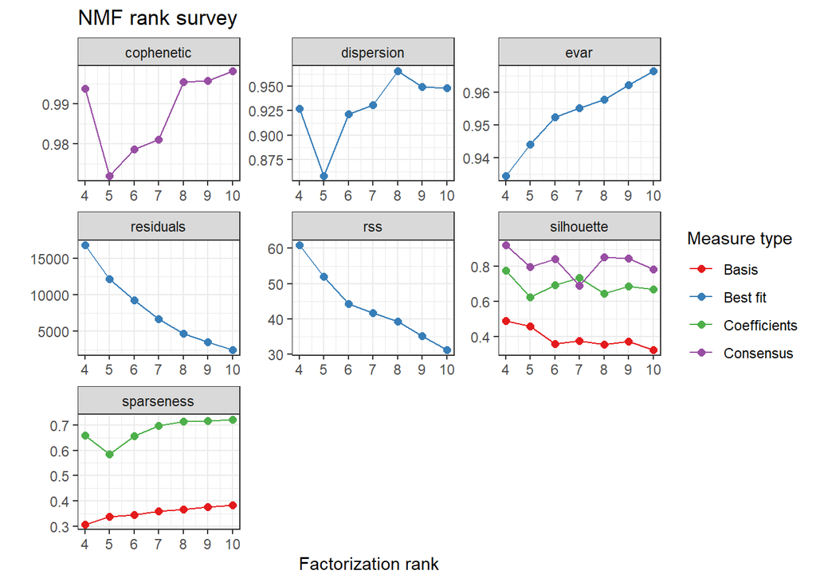

```r
# plots the NMF rank survey
plot(lsnmf_random_less_o3)
```

### Look at 5 factors:

```r
output <- lsnmf_random_less_o3$fit$`5`
W <- basis(output)
H <- coef(output)
```

#### Source Contribution plots

- Source Contribution plots

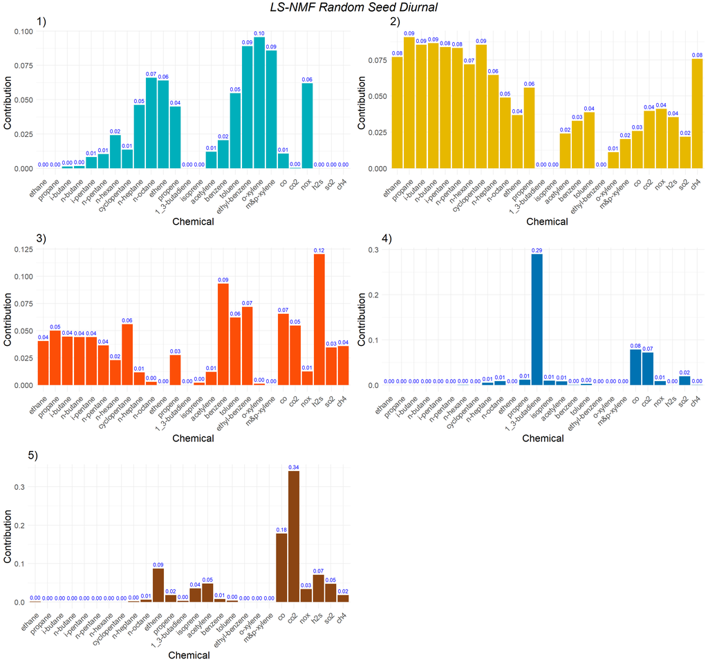

```r
# Convert H to a data frame for ggplot
H_df_5c_less_o3 <- as.data.frame(H)
# Add a column for chemicals
H_df_5c_less_o3$Component <- rownames(H_df_5c_less_o3)

# Reshape data to long format
H_long_5c_less_o3 <- pivot_longer(H_df_5c_less_o3, cols = -Component,
                                  names_to = "Chemical", values_to = "Contribution")

# Plot
nmfplt_1_lsnmf_random_less_o3_5c <- get_component_plot(H_long_5c_less_o3,
                                           '1', '1)')
nmfplt_2_lsnmf_random_less_o3_5c <- get_component_plot(H_long_5c_less_o3,
                                           '2', '2)')
nmfplt_3_lsnmf_random_less_o3_5c <- get_component_plot(H_long_5c_less_o3,
                                           '3', '3)')
nmfplt_4_lsnmf_random_less_o3_5c <- get_component_plot(H_long_5c_less_o3,
                                           '4', '4)')
nmfplt_5_lsnmf_random_less_o3_5c <- get_component_plot(H_long_5c_less_o3,
                                           '5', '5)')
```

#### Fingerprint plot

- Fingerprint plots

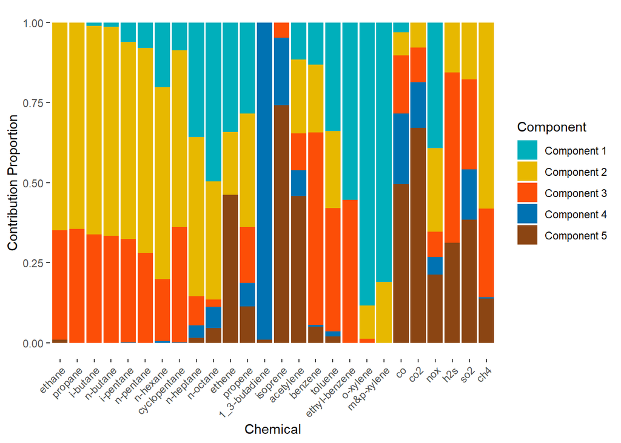

```r
fingerprint <- get_fingerprint_plot(H_df_5c_less_o3, c(
      'Component 1',
      'Component 2',
      'Component 3',
      'Component 4',
      'Component 5'
    ))

fingerprint
```

#### Wind plot

- Wind plots

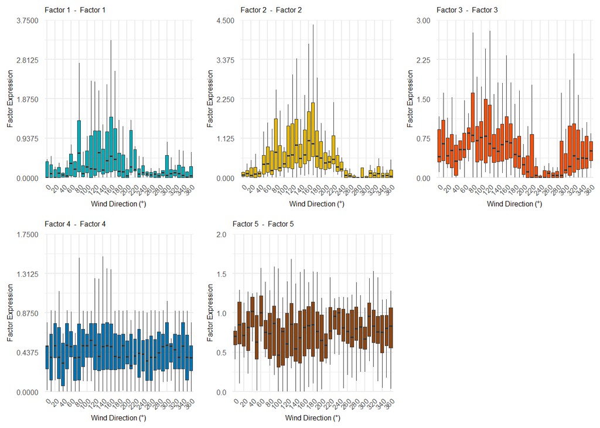

```r
wind_plot <- get_wind_plots(W, y_axis_upper = c(3.75, 4.5, 3, 1.75, 2))

grid.arrange(grobs = wind_plot, ncol = 3)
```

## LS-NMF + nndsvd seed

```r
# Run nmf with 4:10 components and nndsvd seed
# start_time_lsnmf_nndsvd <- Sys.time()
#
# lsnmf_nndsvd_less_o3 <- nmf(
#   normalized_matrix_less_o3,
#   rank = components,
#   nrun = 1, # since using nndsvd
#   method = "ls-nmf",
#   weight = weight_matrix,
#   seed = 'nndsvd'
# )
#
# end_time_lsnmf_nndsvd <- Sys.time()
# end_time_lsnmf_nndsvd-start_time_lsnmf_nndsvd
# 20 seconds to run the above
#
# saveRDS(lsnmf_nndsvd_less_o3,
#         'lsnmf_nndsvd_less_o3_diurnal.rds')

lsnmf_nndsvd_less_o3 <- readRDS('lsnmf_nndsvd_less_o3_diurnal.rds')
```

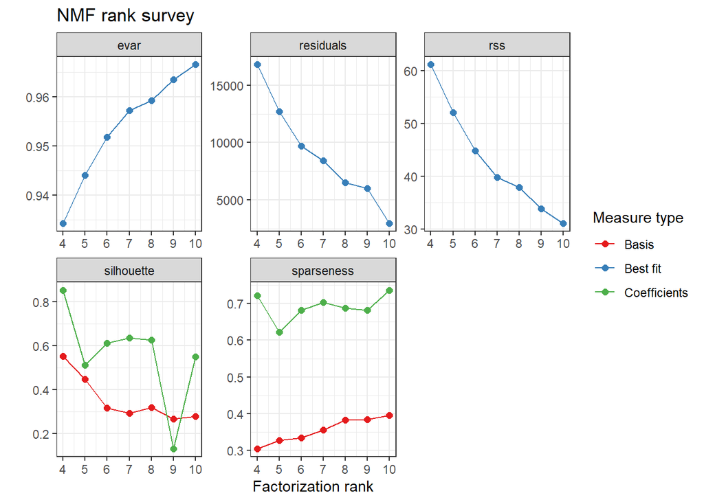

```r
# plots the NMF rank survey
plot(lsnmf_nndsvd_less_o3)
```

### Look at 5 factors:

```r
output <- lsnmf_nndsvd_less_o3$fit$`5`
W <- basis(output)
H <- coef(output)
```

#### Source Contribution plots

- Source Contribution plots

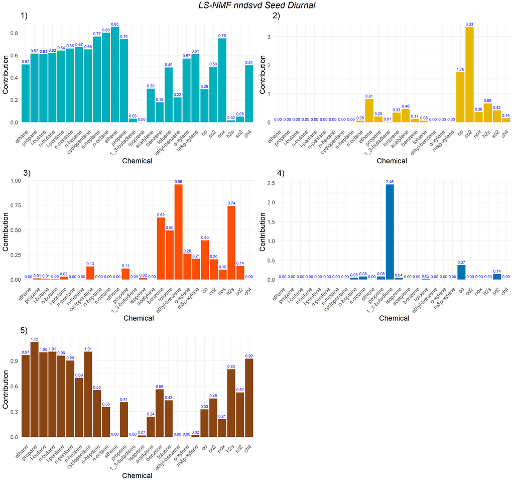

```r
# Convert H to a data frame for ggplot
H_df_5c_less_o3 <- as.data.frame(H)
# Add a column for chemicals
H_df_5c_less_o3$Component <- rownames(H_df_5c_less_o3)

# Reshape data to long format
H_long_5c_less_o3 <- pivot_longer(H_df_5c_less_o3, cols = -Component,
                                  names_to = "Chemical", values_to = "Contribution")

# Plot
nmfplt_1_lsnmf_nndsvd_less_o3_5c <- get_component_plot(H_long_5c_less_o3,
                                           '1', '1)')
nmfplt_2_lsnmf_nndsvd_less_o3_5c <- get_component_plot(H_long_5c_less_o3,
                                           '2', '2)')
nmfplt_3_lsnmf_nndsvd_less_o3_5c <- get_component_plot(H_long_5c_less_o3,
                                           '3', '3)')
nmfplt_4_lsnmf_nndsvd_less_o3_5c <- get_component_plot(H_long_5c_less_o3,
                                           '4', '4)')
nmfplt_5_lsnmf_nndsvd_less_o3_5c <- get_component_plot(H_long_5c_less_o3,
                                           '5', '5)')
```

#### Fingerprint plot

- Fingerprint plots

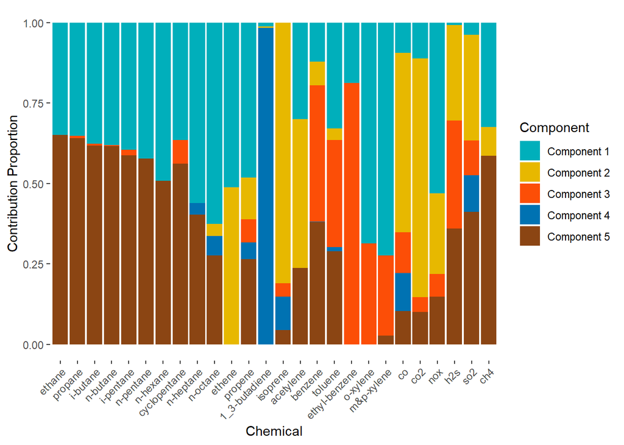

```r
fingerprint <- get_fingerprint_plot(H_df_5c_less_o3, c(
      'Component 1',
      'Component 2',
      'Component 3',
      'Component 4',
      'Component 5'
    ))
fingerprint
```

```r
#ggsave("fingerprint.png", c)
```

#### Wind plot

- Wind plots

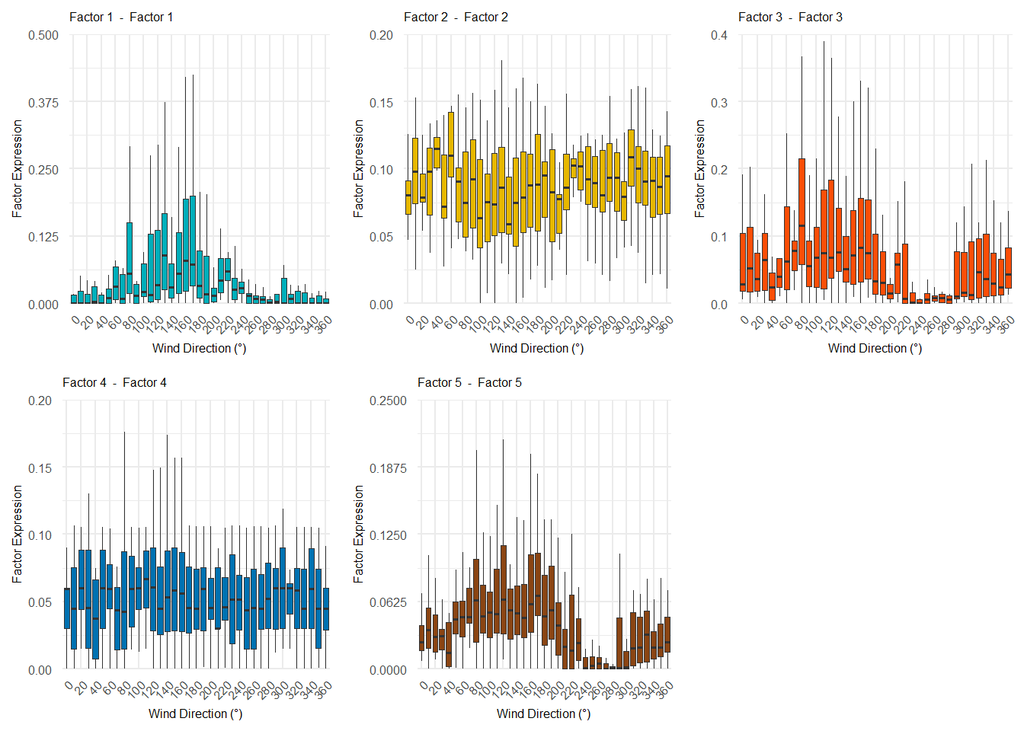

```r
wind_plot <- get_wind_plots(W, y_axis_upper = c(0.5, 0.2, 0.4, 0.2, 0.25))
grid.arrange(grobs = wind_plot, ncol = 3)
```

## Comparing random seed vs nndsvd for ls-nmf

Residuals is defined as sum(((X - fitted(object)) * weight)^2)/2

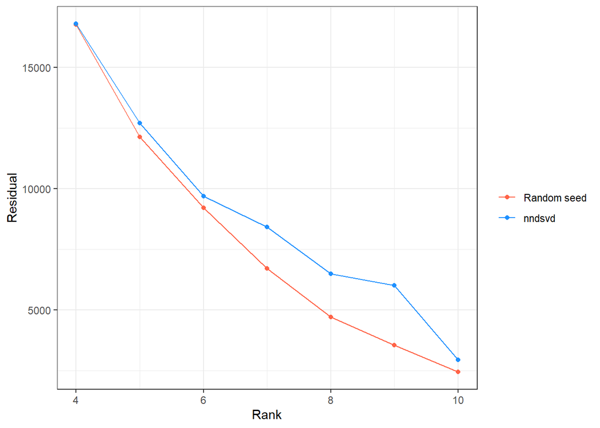

```r
tibble(component = components,
       random_residual = lsnmf_random_less_o3$measures$residuals,
       nndsvd_residual = lsnmf_nndsvd_less_o3$measures$residuals) %>%
  ggplot() +
  geom_line(aes(x = component, y =random_residual, color = 'Random seed')) +
  geom_point(aes(x = component, y =random_residual, color = 'Random seed')) +
  geom_line(aes(x = component, y = nndsvd_residual, color = 'nndsvd')) +
  geom_point(aes(x = component, y = nndsvd_residual, color = 'nndsvd')) +
  scale_colour_manual("",
                    breaks = c("Random seed", "nndsvd"),
                    values = c("tomato1", "dodgerblue")) +
  labs(x = 'Rank', y = 'Residual', 'WRSS') +
  theme_bw()
```

## KL + Random seed

```r
# start_time_kl_random <- Sys.time()
#
# kl_random_less_o3 <- nmf(
#   normalized_matrix_less_o3,
#   rank = components,
#   nrun = 30,
#   method = "KL",
#   seed = 123456
# )
#
# end_time_kl_random <- Sys.time()
# end_time_kl_random-start_time_kl_random
# 3.8 minutes to run the above
#
# saveRDS(kl_random_less_o3, 'kl_random_less_o3_diurnal.rds')

kl_random_less_o3 <- readRDS('kl_random_less_o3_diurnal.rds')
```

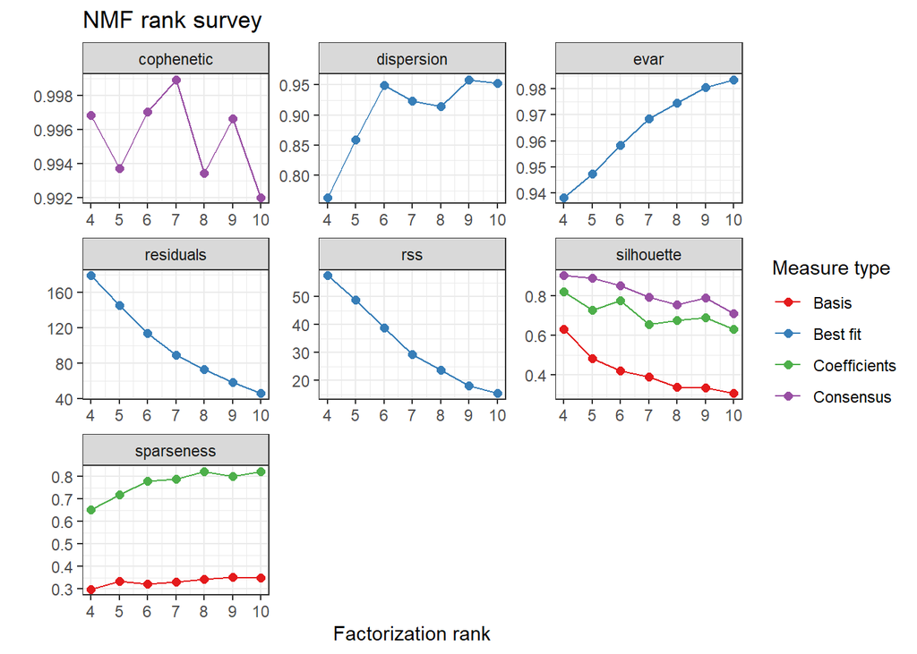

```r
# plots the NMF rank survey
plot(kl_random_less_o3)
```

### Look at 5 factors:

```r
output <- kl_random_less_o3$fit$`5`
W <- basis(output)
H <- coef(output)
```

#### Source Contribution plots

- Source Contribution plots

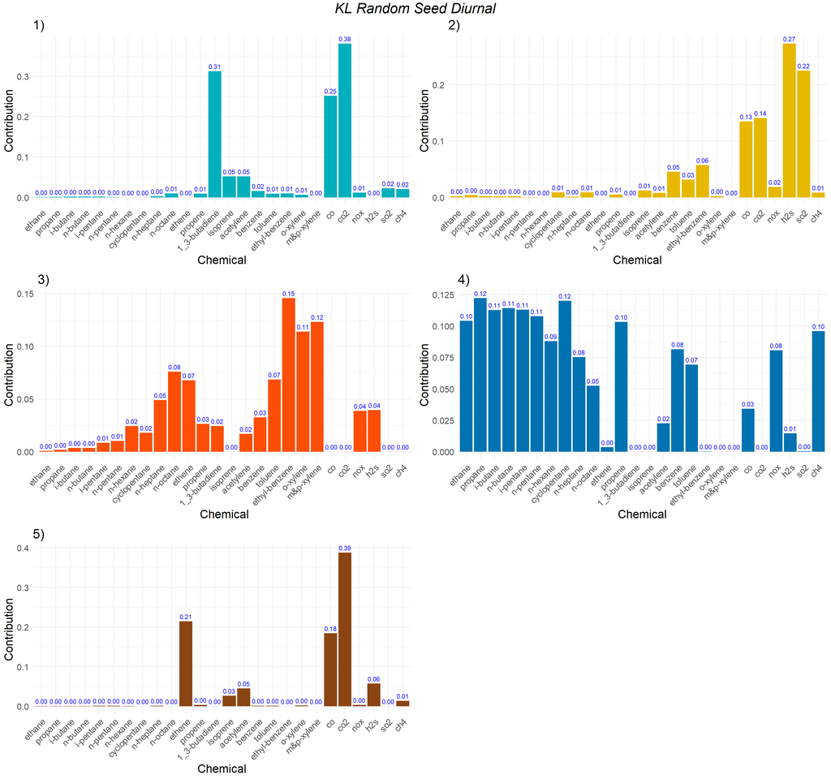

```r
# Convert H to a data frame for ggplot
H_df_5c_less_o3 <- as.data.frame(H)
# Add a column for chemicals
H_df_5c_less_o3$Component <- rownames(H_df_5c_less_o3)

# Reshape data to long format
H_long_5c_less_o3 <- pivot_longer(H_df_5c_less_o3, cols = -Component,
                                  names_to = "Chemical", values_to = "Contribution")

# Plot
nmfplt_1_kl_random_less_o3_5c <- get_component_plot(H_long_5c_less_o3,
                                           '1', '1)')
nmfplt_2_kl_random_less_o3_5c <- get_component_plot(H_long_5c_less_o3,
                                           '2', '2)')
nmfplt_3_kl_random_less_o3_5c <- get_component_plot(H_long_5c_less_o3,
                                           '3', '3)')
nmfplt_4_kl_random_less_o3_5c <- get_component_plot(H_long_5c_less_o3,
                                           '4', '4)')
nmfplt_5_kl_random_less_o3_5c <- get_component_plot(H_long_5c_less_o3,
                                           '5', '5)')
```

#### Fingerprint plot

- Fingerprint plots

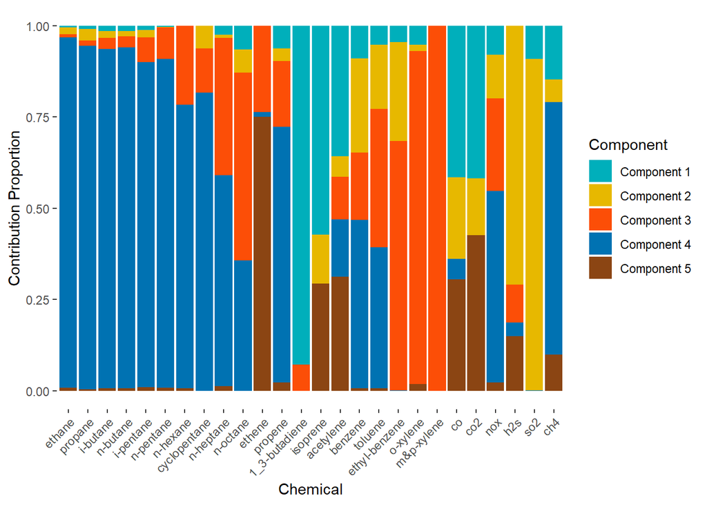

```r
fingerprint <- get_fingerprint_plot(H_df_5c_less_o3, c(
      'Component 1',
      'Component 2',
      'Component 3',
      'Component 4',
      'Component 5'
    ))
fingerprint
```

```r
#ggsave("fingerprint.png", c)
```

#### Wind plot

- Wind plots

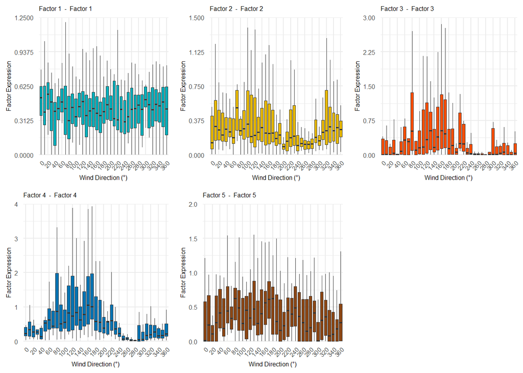

```r
wind_plot <- get_wind_plots(W, y_axis_upper = c(1.25, 1.5, 3, 4, 2))
grid.arrange(grobs = wind_plot, ncol = 3)
```

## KL + nndsvd

```r
# start_time_kl_nndsvd <- Sys.time()
#
# kl_nndsvd_less_o3 <- nmf(
#   normalized_matrix_less_o3,
#   rank = components,
#   nrun = 1,
#   method = "KL",
#   seed = 'nndsvd'
# )
#
# end_time_kl_nndsvd <- Sys.time()
# end_time_kl_nndsvd-start_time_kl_nndsvd
# 14.5 seconds to run the above
#
# saveRDS(kl_nndsvd_less_o3, 'kl_nndsvd_less_o3_diurnal.rds')

kl_nndsvd_less_o3 <- readRDS('kl_nndsvd_less_o3_diurnal.rds')
```

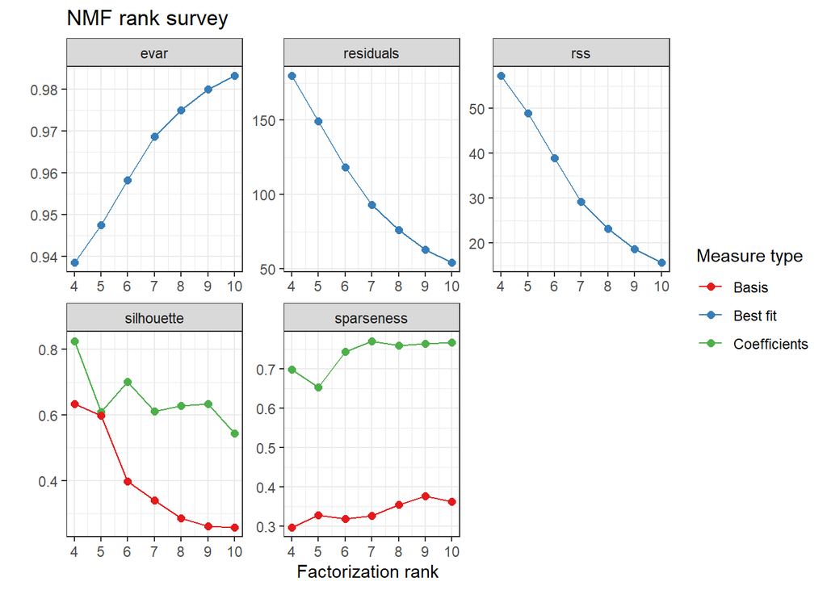

```r
# plots the NMF rank survey
plot(kl_nndsvd_less_o3)
```

### Look at 5 factors:

```r
output <- kl_nndsvd_less_o3$fit$`5`
W <- basis(output)
H <- coef(output)
```

#### Source Contribution plots

- Source Contribution plots

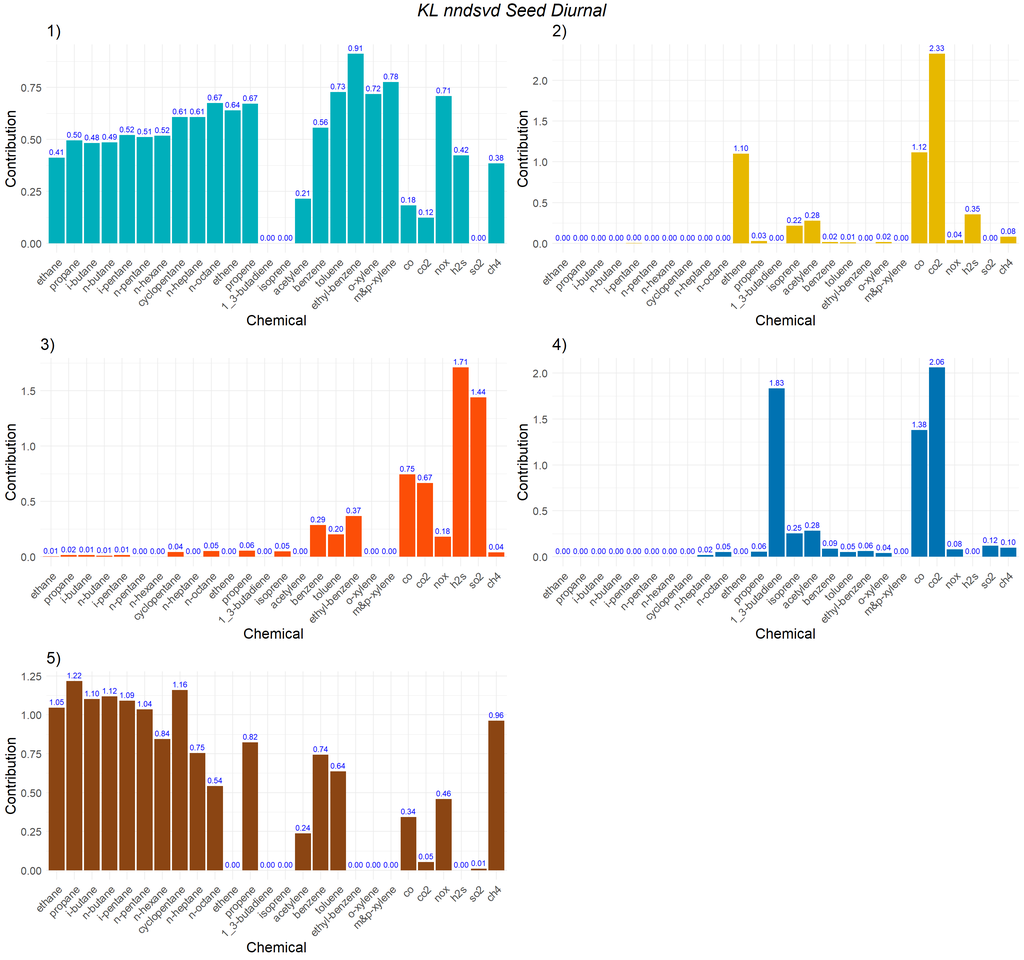

```r
# Convert H to a data frame for ggplot
H_df_5c_less_o3 <- as.data.frame(H)
# Add a column for chemicals
H_df_5c_less_o3$Component <- rownames(H_df_5c_less_o3)

# Reshape data to long format
H_long_5c_less_o3 <- pivot_longer(H_df_5c_less_o3, cols = -Component,
                                  names_to = "Chemical", values_to = "Contribution")

# Plot
nmfplt_1_kl_nndsvd_less_o3_5c <- get_component_plot(H_long_5c_less_o3,
                                           '1', '1)')
nmfplt_2_kl_nndsvd_less_o3_5c <- get_component_plot(H_long_5c_less_o3,
                                           '2', '2)')
nmfplt_3_kl_nndsvd_less_o3_5c <- get_component_plot(H_long_5c_less_o3,
                                           '3', '3)')
nmfplt_4_kl_nndsvd_less_o3_5c <- get_component_plot(H_long_5c_less_o3,
                                           '4', '4)')
nmfplt_5_kl_nndsvd_less_o3_5c <- get_component_plot(H_long_5c_less_o3,
                                           '5', '5)')
```

#### Fingerprint plot

- Fingerprint plots

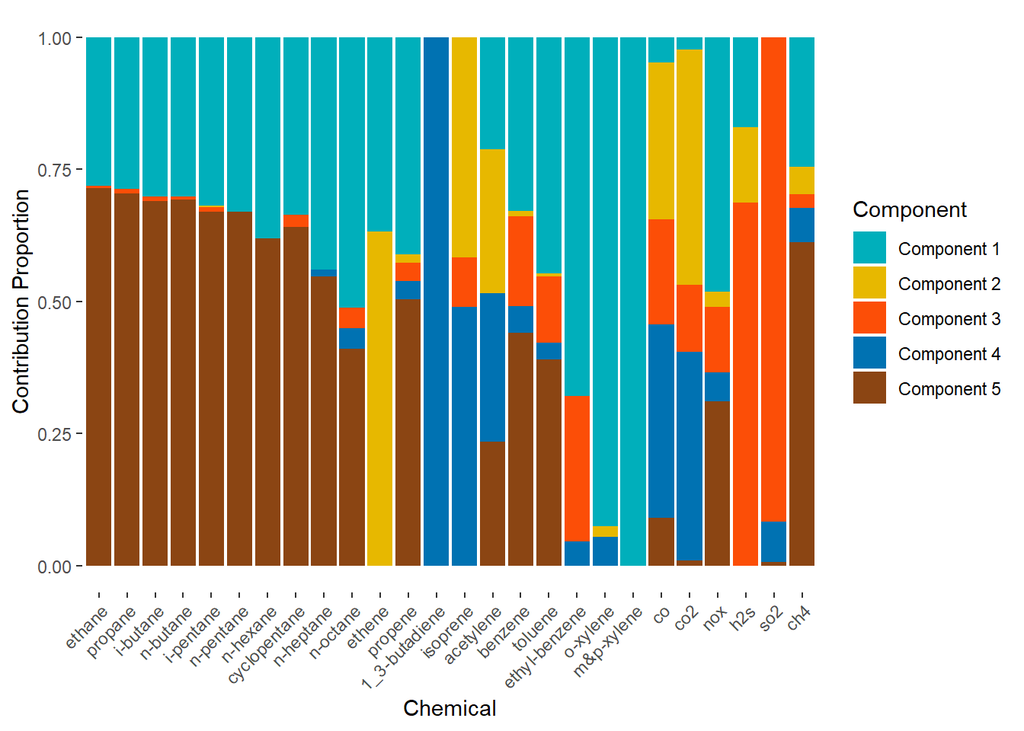

```r
fingerprint <- get_fingerprint_plot(H_df_5c_less_o3, c(
      'Component 1',
      'Component 2',
      'Component 3',
      'Component 4',
      'Component 5'
    ))
fingerprint
```

```r
#ggsave("fingerprint.png", c)
```

#### Wind plot

- Wind plots

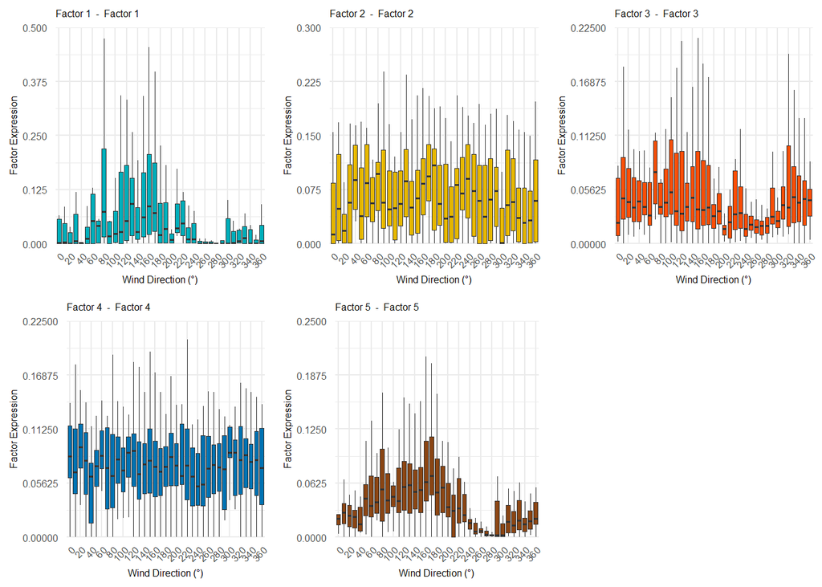

```r
wind_plot <- get_wind_plots(W, y_axis_upper = c(0.5, 0.3, 0.225, 0.225, 0.25))
grid.arrange(grobs = wind_plot, ncol = 3)
```

## Comparing all four methods

Using RSS, WRSS, and KL

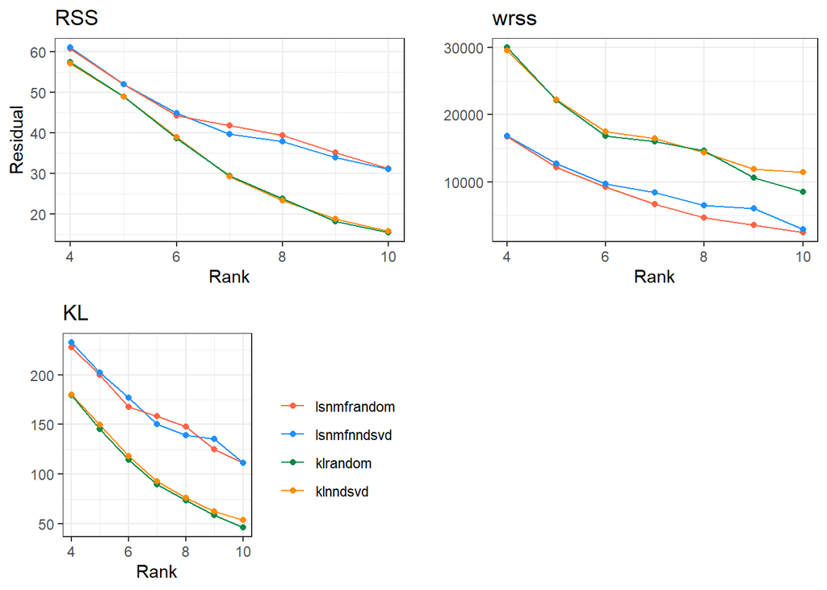

```r
get_residual <- function(component, seed, method, objective) {
  fitted <- fitted(get(paste(method, seed, 'less_o3', sep = '_'))$fit[[component-3]])
  if (objective == 'wrss') {
    return(sum(((normalized_matrix_less_o3 - fitted) * weight_matrix)^2)/2)
  } else if (objective == 'kl') {
    log_term <- normalized_matrix_less_o3/fitted
    log_term[log_term<.Machine$double.eps] <- .Machine$double.eps
    return(sum(normalized_matrix_less_o3 * log(log_term) + fitted - normalized_matrix_less_o3))
  } else if (objective == 'rss') {
    return(norm(normalized_matrix_less_o3 - fitted, type = 'F')^2)
  }
}

df_plot <- expand_grid(
  component = components,
  seed = c('random', 'nndsvd'),
  method = c('lsnmf', 'kl'),
  objective = c('rss', 'wrss', 'kl')
) %>%
  rowwise() %>%
  mutate(residual = get_residual(component, seed, method, objective)) %>%
  ungroup() %>%
  mutate(model = paste0(method, seed))

RSS_plot <- df_plot %>%
  filter(objective=='rss') %>%
  ggplot() +
  geom_line(aes(x = component, y = residual, group = model, color = model)) +
  geom_point(aes(x = component, y = residual, group = model, color = model)) +
  scale_colour_manual("",
                    breaks = c("lsnmfrandom", "lsnmfnndsvd",
                               "klrandom", "klnndsvd"),
                    values = c("tomato1", "dodgerblue",
                               "springgreen4", "darkorange")) +
  labs(x = 'Rank', y = 'Residual', title = 'RSS') +
  theme_bw() +
  theme(legend.position="none")

WRSS_plot <- df_plot %>%
  filter(objective=='wrss') %>%
  ggplot() +
  geom_line(aes(x = component, y = residual, group = model, color = model)) +
  geom_point(aes(x = component, y = residual, group = model, color = model)) +
  scale_colour_manual("",
                  breaks = c("lsnmfrandom", "lsnmfnndsvd",
                             "klrandom", "klnndsvd"),
                  values = c("tomato1", "dodgerblue",
                             "springgreen4", "darkorange")) +
  labs(x = 'Rank', y = '', title = 'wrss') +
  theme_bw() +
  theme(legend.position="none")

KL_plot <- df_plot %>%
  filter(objective=='kl') %>%
  ggplot() +
  geom_line(aes(x = component, y = residual, group = model, color = model)) +
  geom_point(aes(x = component, y = residual, group = model, color = model)) +
  scale_colour_manual("",
                    breaks = c("lsnmfrandom", "lsnmfnndsvd",
                               "klrandom", "klnndsvd"),
                    values = c("tomato1", "dodgerblue",
                               "springgreen4", "darkorange")) +
  labs(x = 'Rank', y = '', title = 'KL') +
  theme_bw()
grid.arrange(RSS_plot, WRSS_plot, KL_plot, ncol=2)
```

## NMF with 5 source factors without ozone

```r
nmf_result_5c_less_o3 <- lsnmf_nndsvd_less_o3$fit$`5`

basis_matrix_5c_less_o3 <- basis(nmf_result_5c_less_o3) #W
coef_matrix_5c_less_o3 <- coef(nmf_result_5c_less_o3) #H

# get variance explained by the factors (WRSS)
reconstruct<-fitted(nmf_result_5c_less_o3)

# Traditional way of computing WRSS = sum of weight * (X - Xhat)^2
wtss_trad <- sum(weight_matrix * (normalized_matrix_less_o3 - mean(normalized_matrix_less_o3))^2)
wrss_trad <- sum(weight_matrix * (normalized_matrix_less_o3 - reconstruct)^2)
variance_explained_trad <- 1 - (wrss_trad / wtss_trad)
cat('Variance explained (Traditional WRSS): ', round(variance_explained_trad*100, 2), '%', sep = '')
```

```
## Variance explained (Traditional WRSS): 95.38%
```

```r
# How the NMF package computes WRSS = sum of 0.5 * (weight * (X - Xhat))^2
wtss_pkg <- sum((weight_matrix * (normalized_matrix_less_o3 - mean(normalized_matrix_less_o3)))^2/2)
wrss_pkg <- sum((weight_matrix * (normalized_matrix_less_o3 - reconstruct))^2/2)
variance_explained_pkg <- 1 - (wrss_pkg / wtss_pkg)
cat('Variance explained (Package WRSS): ', round(variance_explained_pkg*100, 2), '%', sep = '')
```

```
## Variance explained (Package WRSS): 96.75%
```

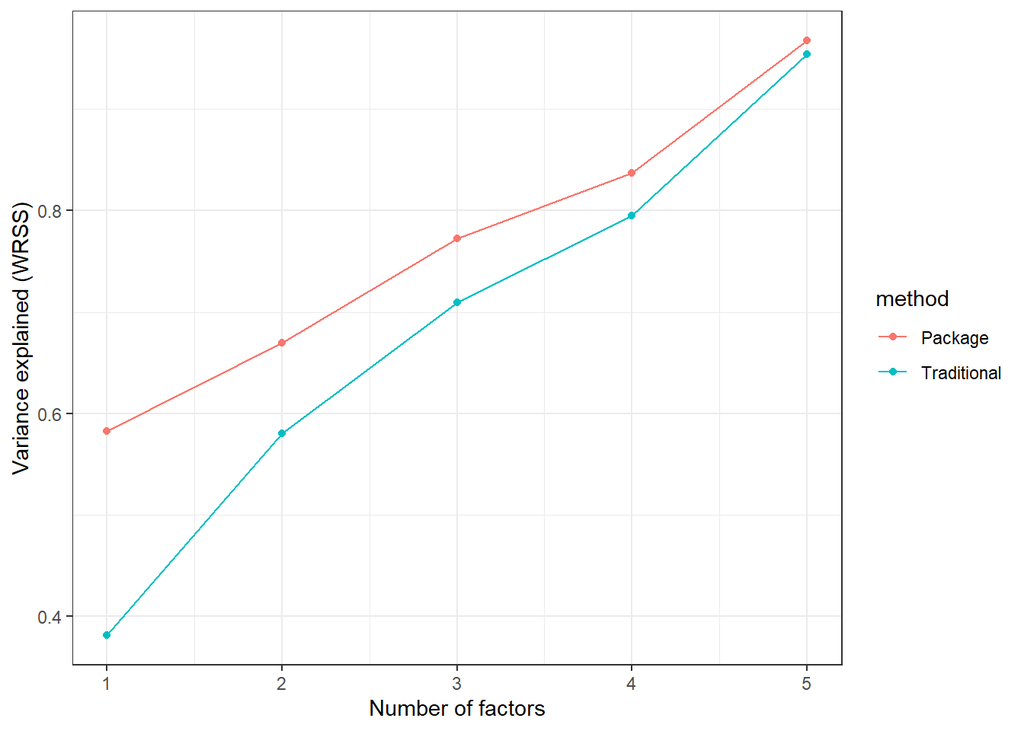

```r
# get variance explained by each factor separately
# Compute variance explained by each factor
# Initialize variance explained tracker
variance_explained_trad_factors <- numeric(5)
variance_explained_pkg_factors <- numeric(5)

# Incrementally add factors and calculate variance explained
reconstruction <- matrix(0, nrow = nrow(basis_matrix_5c_less_o3), ncol = ncol(coef_matrix_5c_less_o3))

for (i in 1:5) {
  # Add the i-th factor to the reconstruction
  reconstruction <- reconstruction + (basis_matrix_5c_less_o3[, i, drop=FALSE] %*% coef_matrix_5c_less_o3[i, , drop=FALSE])

  # Compute Residual Sum of Squares (RSS)
  wrss_temp_trad <- sum(weight_matrix * (normalized_matrix_less_o3 - reconstruction)^2)
  wrss_temp_pkg <- sum((weight_matrix * (normalized_matrix_less_o3 - reconstruction))^2/2)

  # Compute Variance Explained by adding this factor
  variance_explained_trad_factors[i] <- 1 - (wrss_temp_trad / wtss_trad)
  variance_explained_pkg_factors[i] <- 1 - (wrss_temp_pkg / wtss_pkg)
}

# Plot variance explained by each factor cumulatively
tibble(factor = c(1:length(variance_explained_trad_factors),
                  1:length(variance_explained_pkg_factors)),
       var_exp = c(variance_explained_trad_factors, variance_explained_pkg_factors),
       method = c(rep('Traditional', length(variance_explained_trad_factors)),
                  rep('Package', length(variance_explained_pkg_factors)))) %>%
  ggplot() +
  geom_line(aes(x = factor, y = var_exp, color = method)) +
  geom_point(aes(x = factor, y = var_exp, color = method)) +
  labs(x = 'Number of factors', y = 'Variance explained (WRSS)') +
  theme_bw()
```

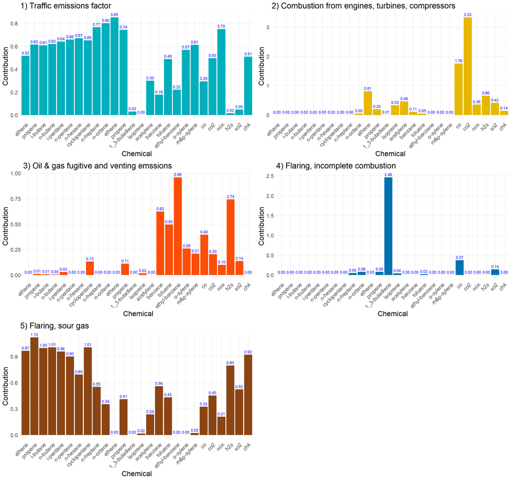

```r
# Convert H to a data frame for ggplot
H_df_5c_less_o3 <- as.data.frame(coef_matrix_5c_less_o3)
# Add a column for chemicals
H_df_5c_less_o3$Component <- rownames(H_df_5c_less_o3)

# Reshape data to long format
H_long_5c_less_o3 <- pivot_longer(H_df_5c_less_o3, cols = -Component,
                                  names_to = "Chemical", values_to = "Contribution")

# Plot
nmfplt_1_svd_5c_less_o3 <- get_component_plot(H_long_5c_less_o3,
                                           '1', '1) Traffic emissions factor')
nmfplt_2_svd_5c_less_o3 <- get_component_plot(H_long_5c_less_o3,
                                           '2', '2) Combustion from engines, turbines, compressors')
nmfplt_3_svd_5c_less_o3 <- get_component_plot(H_long_5c_less_o3,
                                           '3', '3) Oil & gas fugitive and venting emssions')
nmfplt_4_svd_5c_less_o3 <- get_component_plot(H_long_5c_less_o3,
                                           '4', '4) Flaring, incomplete combustion')
nmfplt_5_svd_5c_less_o3 <- get_component_plot(H_long_5c_less_o3,
                                           '5', '5) Flaring, sour gas')
```

## Factor analysis

- merge in factors 1-5 to dataset (hourly)

```r
# First look at how well this approximates
fitted_5c_less_o3 <- fitted(nmf_result_5c_less_o3)
sum(abs(normalized_matrix_less_o3-fitted_5c_less_o3))
```

```
## [1] 593.2511
```

```r
# NMF factorizes V = WH
# Store Basis matrix (W) and Coef Matrix (H)
saveRDS(basis_matrix_5c_less_o3, 'result_rfiles/nmf_norm_5c_less_o3_basis_diurnal.rds')
saveRDS(coef_matrix_5c_less_o3, 'result_rfiles/nmf_norm_5c_less_o3_coef_diurnal.rds')

# Merge basis matrix into hourly observations
basis_matrix_5c_less_o3 <- as_tibble(basis_matrix_5c_less_o3) %>%
  setNames(c('Factor1', 'Factor2', 'Factor3', 'Factor4', 'Factor5'))
normalized_hourly_data_diurnal_5c_less_o3_diurnal <- hourly_nona_diurnal[,c('day', 'time_utc')] %>%
  cbind(normalized_matrix_less_o3) %>%
  cbind(basis_matrix_5c_less_o3) %>%
  right_join(hourly_data_diurnal %>% select(-'day'), join_by(time_utc), suffix = c('_norm', ''))

# saveRDS(normalized_hourly_data_diurnal_5c_less_o3,
#  'result_rfiles/normalized_hourly_data_diurnal_5c_less_o3_diurnal.rds')
normalized_hourly_data_5c_less_o3_diurnal <- readRDS('result_rfiles/normalized_hourly_data_diurnal_5c_less_o3_diurnal.rds')
```

- make daily dataset for VNF analysis
- compute wind directions from plots

```r
# Also compute a daily dataset
normalized_daily_data_5c_less_o3_diurnal <- normalized_hourly_data_5c_less_o3_diurnal %>%
  group_by(day) %>%
  summarise(across(where(is.numeric) & !any_of('wdr_deg'), ~ mean(.x, na.rm = T)),
            wdr_deg = as.numeric(mean(circular(wdr_deg, units = "degrees"), na.rm = T))) %>%
  mutate(wdr_deg = if_else(wdr_deg < 0, wdr_deg+360, wdr_deg)) %>%
  mutate(wind_45_135 = wdr_deg >= 45 & wdr_deg < 135,
         wind_135_180 = wdr_deg >= 135 & wdr_deg < 180,
         wind_180_270 = wdr_deg >= 180 & wdr_deg < 270,
         wind_270_45 = wdr_deg >= 270 & wdr_deg < 45)

# saveRDS(normalized_daily_data_5c_less_o3_diurnal,
#  'result_rfiles/normalized_daily_data_5c_less_o3_diurnal.rds')

normalized_daily_data_5c_less_o3 <-
  readRDS('result_rfiles/normalized_daily_data_5c_less_o3_diurnal.rds')
```

- 1. number of flares in 100km of trailer associated with NMF
- 2. weighted count based on distance to trailer

```r
# Check if relationship between # flares and flare factor (4 & 5)
# Linear model
flare_factor <- lm(n_flare_100 ~ Factor1 + Factor2 + Factor3 + Factor4 + Factor5,
                   data = normalized_daily_data_5c_less_o3)
summary(flare_factor)
```

```
##
## Call:
## lm(formula = n_flare_100 ~ Factor1 + Factor2 + Factor3 + Factor4 +
##     Factor5, data = normalized_daily_data_5c_less_o3)
##
## Residuals:
##     Min      1Q  Median      3Q     Max
## -55.810 -21.350   3.264  17.524  63.890
##
## Coefficients:
##             Estimate Std. Error t value Pr(>|t|)
## (Intercept)   67.636      7.012   9.645  < 2e-16 ***
## Factor1      -36.887     22.780  -1.619  0.10666
## Factor2     -188.319     41.128  -4.579 7.39e-06 ***
## Factor3     -100.897     43.052  -2.344  0.01988 *
## Factor4     -193.936     74.204  -2.614  0.00951 **
## Factor5      222.766     43.955   5.068 7.84e-07 ***
## ---
## Signif. codes:  0 '***' 0.001 '**' 0.01 '*' 0.05 '.' 0.1 ' ' 1
##
## Residual standard error: 26.87 on 249 degrees of freedom
##   (1 observation deleted due to missingness)
## Multiple R-squared:  0.1383, Adjusted R-squared:  0.121
## F-statistic: 7.991 on 5 and 249 DF,  p-value: 5.275e-07
```

```r
flare_factor45 <- lm(n_flare_100 ~ Factor4 + Factor5, data = normalized_daily_data_5c_less_o3)
summary(flare_factor45)
```

```
##
## Call:
## lm(formula = n_flare_100 ~ Factor4 + Factor5, data = normalized_daily_data_5c_less_o3)
##
## Residuals:
##     Min      1Q  Median      3Q     Max
## -52.591 -26.034   5.761  18.740  76.871
##
## Coefficients:
##             Estimate Std. Error t value Pr(>|t|)
## (Intercept)   47.528      4.765   9.975   <2e-16 ***
## Factor4     -102.785     63.360  -1.622   0.1060
## Factor5       80.078     33.559   2.386   0.0178 *
## ---
## Signif. codes:  0 '***' 0.001 '**' 0.01 '*' 0.05 '.' 0.1 ' ' 1
##
## Residual standard error: 28.42 on 252 degrees of freedom
##   (1 observation deleted due to missingness)
## Multiple R-squared:  0.02467,    Adjusted R-squared:  0.01693
## F-statistic: 3.187 on 2 and 252 DF,  p-value: 0.04296
```

```r
flare_factor_weighted <- lm(weighted.count ~ Factor1 + Factor2 + Factor3 + Factor4 + Factor5,
                            data = normalized_daily_data_5c_less_o3)
summary(flare_factor_weighted)
```

```
##
## Call:
## lm(formula = weighted.count ~ Factor1 + Factor2 + Factor3 + Factor4 +
##     Factor5, data = normalized_daily_data_5c_less_o3)
##
## Residuals:
##     Min      1Q  Median      3Q     Max
## -2.3229 -0.2749  0.0561  0.3838  4.0968
##
## Coefficients:
##             Estimate Std. Error t value Pr(>|t|)
## (Intercept)   2.4871     0.2261  11.002   <2e-16 ***
## Factor1      -0.7868     0.7344  -1.071   0.2850
## Factor2      -3.2556     1.3259  -2.455   0.0148 *
## Factor3      -0.7215     1.3879  -0.520   0.6037
## Factor4      -2.3909     2.3922  -0.999   0.3185
## Factor5       2.0239     1.4170   1.428   0.1545
## ---
## Signif. codes:  0 '***' 0.001 '**' 0.01 '*' 0.05 '.' 0.1 ' ' 1
##
## Residual standard error: 0.8664 on 249 degrees of freedom
##   (1 observation deleted due to missingness)
## Multiple R-squared:  0.03739,    Adjusted R-squared:  0.01806
## F-statistic: 1.934 on 5 and 249 DF,  p-value: 0.08918
```

```r
flare_factor_weighted45 <- lm(weighted.count ~ Factor4 + Factor5,
                              data = normalized_daily_data_5c_less_o3)
summary(flare_factor_weighted45)
```

```
##
## Call:
## lm(formula = weighted.count ~ Factor4 + Factor5, data = normalized_daily_data_5c_less_o3)
##
## Residuals:
##     Min      1Q  Median      3Q     Max
## -2.1467 -0.1823  0.0846  0.3968  3.8674
##
## Coefficients:
##             Estimate Std. Error t value Pr(>|t|)
## (Intercept)   2.2018     0.1470  14.982   <2e-16 ***
## Factor4      -1.2775     1.9543  -0.654    0.514
## Factor5      -0.2397     1.0351  -0.232    0.817
## ---
## Signif. codes:  0 '***' 0.001 '**' 0.01 '*' 0.05 '.' 0.1 ' ' 1
##
## Residual standard error: 0.8766 on 252 degrees of freedom
##   (1 observation deleted due to missingness)
## Multiple R-squared:  0.002671,   Adjusted R-squared:  -0.005244
## F-statistic: 0.3375 on 2 and 252 DF,  p-value: 0.7139
```

```r
# All factors + wind speed + wind direction + factor5:sw wind.
# Wind direction from 270 to 45 is left as reference group.
flare_factor_weighted_2 <- lm(weighted.count ~ Factor1 + Factor2 + Factor3 +
                                Factor4 + Factor5 + wsp_ms + wind_45_135 +
                                wind_135_180 + Factor5*wind_180_270,
                              data = normalized_daily_data_5c_less_o3)
summary(flare_factor_weighted_2)
```

```
##
## Call:
## lm(formula = weighted.count ~ Factor1 + Factor2 + Factor3 + Factor4 +
##     Factor5 + wsp_ms + wind_45_135 + wind_135_180 + Factor5 *
##     wind_180_270, data = normalized_daily_data_5c_less_o3)
##
## Residuals:
##     Min      1Q  Median      3Q     Max
## -2.3149 -0.2685  0.0819  0.3822  4.0095
##
## Coefficients:
##                          Estimate Std. Error t value Pr(>|t|)
## (Intercept)               2.50494    0.27397   9.143   <2e-16 ***
## Factor1                  -0.46315    0.75178  -0.616   0.5384
## Factor2                  -3.19311    1.34421  -2.375   0.0183 *
## Factor3                  -1.08708    1.44353  -0.753   0.4521
## Factor4                  -3.34778    2.43224  -1.376   0.1700
## Factor5                   3.00430    1.62642   1.847   0.0659 .
## wsp_ms                    0.03561    0.02694   1.322   0.1874
## wind_45_135TRUE          -0.11475    0.18143  -0.632   0.5277
## wind_135_180TRUE         -0.29138    0.16045  -1.816   0.0706 .
## wind_180_270TRUE         -0.27265    0.19584  -1.392   0.1651
## Factor5:wind_180_270TRUE  1.13863    2.94806   0.386   0.6997
## ---
## Signif. codes:  0 '***' 0.001 '**' 0.01 '*' 0.05 '.' 0.1 ' ' 1
##
## Residual standard error: 0.865 on 244 degrees of freedom
##   (1 observation deleted due to missingness)
## Multiple R-squared:  0.05977,    Adjusted R-squared:  0.02124
## F-statistic: 1.551 on 10 and 244 DF,  p-value: 0.1221
```

```r
# Same as above but only factor 4 and 5
flare_factor_weighted_3 <- lm(weighted.count ~ Factor4 + Factor5 + wsp_ms +
                                Factor5*wind_180_270,
                              data = normalized_daily_data_5c_less_o3)
summary(flare_factor_weighted_3)
```

```
##
## Call:
## lm(formula = weighted.count ~ Factor4 + Factor5 + wsp_ms + Factor5 *
##     wind_180_270, data = normalized_daily_data_5c_less_o3)
##
## Residuals:
##     Min      1Q  Median      3Q     Max
## -2.2145 -0.1809  0.0938  0.3919  3.8965
##
## Coefficients:
##                          Estimate Std. Error t value Pr(>|t|)
## (Intercept)               2.08635    0.18583  11.227   <2e-16 ***
## Factor4                  -1.95556    1.98578  -0.985   0.3257
## Factor5                  -0.07211    1.14631  -0.063   0.9499
## wsp_ms                    0.04395    0.02500   1.758   0.0799 .
## wind_180_270TRUE         -0.27643    0.18640  -1.483   0.1393
## Factor5:wind_180_270TRUE  3.68407    2.84549   1.295   0.1966
## ---
## Signif. codes:  0 '***' 0.001 '**' 0.01 '*' 0.05 '.' 0.1 ' ' 1
##
## Residual standard error: 0.874 on 249 degrees of freedom
##   (1 observation deleted due to missingness)
## Multiple R-squared:  0.02039,    Adjusted R-squared:  0.000716
## F-statistic: 1.036 on 5 and 249 DF,  p-value: 0.3967
```

```r
# Same as above but interaction between factor 4 and SW wind
flare_factor_weighted_3b <- lm(weighted.count ~ Factor4 + Factor5 + wsp_ms +
                                 Factor4*wind_180_270,
                               data = normalized_daily_data_5c_less_o3)
summary(flare_factor_weighted_3b)
```

```
##
## Call:
## lm(formula = weighted.count ~ Factor4 + Factor5 + wsp_ms + Factor4 *
##     wind_180_270, data = normalized_daily_data_5c_less_o3)
##
## Residuals:
##     Min      1Q  Median      3Q     Max
## -2.2372 -0.1787  0.0707  0.4154  3.8566
##
## Coefficients:
##                          Estimate Std. Error t value Pr(>|t|)
## (Intercept)               2.17826    0.19619  11.103   <2e-16 ***
## Factor4                  -3.46496    2.22165  -1.560   0.1201
## Factor5                   0.31826    1.10486   0.288   0.7735
## wsp_ms                    0.04350    0.02478   1.755   0.0804 .
## wind_180_270TRUE         -0.68149    0.34048  -2.002   0.0464 *
## Factor4:wind_180_270TRUE  7.63810    4.18005   1.827   0.0689 .
## ---
## Signif. codes:  0 '***' 0.001 '**' 0.01 '*' 0.05 '.' 0.1 ' ' 1
##
## Residual standard error: 0.8711 on 249 degrees of freedom
##   (1 observation deleted due to missingness)
## Multiple R-squared:  0.02684,    Adjusted R-squared:  0.0073
## F-statistic: 1.374 on 5 and 249 DF,  p-value: 0.2347
```

```r
# Same as above but with East wind
flare_factor_weighted_3c <- lm(weighted.count ~ Factor4 + Factor5 + wsp_ms +
                                 Factor5*wind_45_135,
                               data = normalized_daily_data_5c_less_o3)
summary(flare_factor_weighted_3c)
```

```
##
## Call:
## lm(formula = weighted.count ~ Factor4 + Factor5 + wsp_ms + Factor5 *
##     wind_45_135, data = normalized_daily_data_5c_less_o3)
##
## Residuals:
##     Min      1Q  Median      3Q     Max
## -2.2786 -0.1527  0.0762  0.4129  3.9662
##
## Coefficients:
##                         Estimate Std. Error t value Pr(>|t|)
## (Intercept)              2.00236    0.20162   9.932   <2e-16 ***
## Factor4                 -1.38468    1.98223  -0.699    0.485
## Factor5                  0.24321    1.15468   0.211    0.833
## wsp_ms                   0.04009    0.02622   1.529    0.127
## wind_45_135TRUE         -0.02623    0.28325  -0.093    0.926
## Factor5:wind_45_135TRUE  1.64419    3.85969   0.426    0.670
## ---
## Signif. codes:  0 '***' 0.001 '**' 0.01 '*' 0.05 '.' 0.1 ' ' 1
##
## Residual standard error: 0.8774 on 249 degrees of freedom
##   (1 observation deleted due to missingness)
## Multiple R-squared:  0.01278,    Adjusted R-squared:  -0.007046
## F-statistic: 0.6446 on 5 and 249 DF,  p-value: 0.6659
```

```r
flare_factor_weighted_3d <- lm(weighted.count ~ Factor4 + Factor5 + wsp_ms +
                                 Factor4*wind_45_135,
                               data = normalized_daily_data_5c_less_o3)
summary(flare_factor_weighted_3d)
```

```
##
## Call:
## lm(formula = weighted.count ~ Factor4 + Factor5 + wsp_ms + Factor4 *
##     wind_45_135, data = normalized_daily_data_5c_less_o3)
##
## Residuals:
##     Min      1Q  Median      3Q     Max
## -2.2672 -0.1476  0.0800  0.4149  3.9860
##
## Coefficients:
##                         Estimate Std. Error t value Pr(>|t|)
## (Intercept)              1.96531    0.20704   9.492   <2e-16 ***
## Factor4                 -0.98285    2.07512  -0.474    0.636
## Factor5                  0.29319    1.11715   0.262    0.793
## wsp_ms                   0.04095    0.02621   1.562    0.119
## wind_45_135TRUE          0.41844    0.48547   0.862    0.390
## Factor4:wind_45_135TRUE -4.90555    6.54258  -0.750    0.454
## ---
## Signif. codes:  0 '***' 0.001 '**' 0.01 '*' 0.05 '.' 0.1 ' ' 1
##
## Residual standard error: 0.8767 on 249 degrees of freedom
##   (1 observation deleted due to missingness)
## Multiple R-squared:  0.01428,    Adjusted R-squared:  -0.005509
## F-statistic: 0.7217 on 5 and 249 DF,  p-value: 0.6077
```

```r
# Wind speed + factor 4 and interaction with East wind
flare_factor_weighted_4a <- lm(weighted.count ~ wsp_ms + Factor4*wind_45_135,
                               data = normalized_daily_data_5c_less_o3)
summary(flare_factor_weighted_4a)
```

```
##
## Call:
## lm(formula = weighted.count ~ wsp_ms + Factor4 * wind_45_135,
##     data = normalized_daily_data_5c_less_o3)
##
## Residuals:
##     Min      1Q  Median      3Q     Max
## -2.2680 -0.1515  0.0759  0.4046  3.9762
##
## Coefficients:
##                         Estimate Std. Error t value Pr(>|t|)
## (Intercept)              1.97663    0.20212   9.779   <2e-16 ***
## wsp_ms                   0.03855    0.02452   1.572    0.117
## Factor4                 -0.78108    1.92387  -0.406    0.685
## wind_45_135TRUE          0.42822    0.48314   0.886    0.376
## Factor4:wind_45_135TRUE -5.07249    6.49945  -0.780    0.436
## ---
## Signif. codes:  0 '***' 0.001 '**' 0.01 '*' 0.05 '.' 0.1 ' ' 1
##
## Residual standard error: 0.8751 on 250 degrees of freedom
##   (1 observation deleted due to missingness)
## Multiple R-squared:  0.01401,    Adjusted R-squared:  -0.001764
## F-statistic: 0.8882 on 4 and 250 DF,  p-value: 0.4716
```

```r
# Wind speed + factor 4 and interaction with SE wind
flare_factor_weighted_4b <- lm(weighted.count ~ wsp_ms + Factor4*wind_135_180,
                               data = normalized_daily_data_5c_less_o3)
summary(flare_factor_weighted_4b)
```

```
##
## Call:
## lm(formula = weighted.count ~ wsp_ms + Factor4 * wind_135_180,
##     data = normalized_daily_data_5c_less_o3)
##
## Residuals:
##     Min      1Q  Median      3Q     Max
## -2.2410 -0.1785  0.0679  0.4008  3.9551
##
## Coefficients:
##                          Estimate Std. Error t value Pr(>|t|)
## (Intercept)               1.96686    0.21777   9.032   <2e-16 ***
## wsp_ms                    0.02916    0.02276   1.281    0.201
## Factor4                   0.71421    2.58050   0.277    0.782
## wind_135_180TRUE          0.13063    0.30395   0.430    0.668
## Factor4:wind_135_180TRUE -3.56532    3.67649  -0.970    0.333
## ---
## Signif. codes:  0 '***' 0.001 '**' 0.01 '*' 0.05 '.' 0.1 ' ' 1
##
## Residual standard error: 0.8725 on 250 degrees of freedom
##   (1 observation deleted due to missingness)
## Multiple R-squared:  0.01993,    Adjusted R-squared:  0.004248
## F-statistic: 1.271 on 4 and 250 DF,  p-value: 0.2819
```

```r
# Wind speed + factor 4 and interaction with SW wind
flare_factor_weighted_4c <- lm(weighted.count ~ wsp_ms + Factor4*wind_180_270,
                               data = normalized_daily_data_5c_less_o3)
summary(flare_factor_weighted_4c)
```

```
##
## Call:
## lm(formula = weighted.count ~ wsp_ms + Factor4 * wind_180_270,
##     data = normalized_daily_data_5c_less_o3)
##
## Residuals:
##     Min      1Q  Median      3Q     Max
## -2.2388 -0.1828  0.0713  0.4083  3.8457
##
## Coefficients:
##                          Estimate Std. Error t value Pr(>|t|)
## (Intercept)               2.19092    0.19085  11.480   <2e-16 ***
## wsp_ms                    0.04104    0.02322   1.767   0.0784 .
## Factor4                  -3.25754    2.09788  -1.553   0.1217
## wind_180_270TRUE         -0.68283    0.33983  -2.009   0.0456 *
## Factor4:wind_180_270TRUE  7.63075    4.17230   1.829   0.0686 .
## ---
## Signif. codes:  0 '***' 0.001 '**' 0.01 '*' 0.05 '.' 0.1 ' ' 1
##
## Residual standard error: 0.8695 on 250 degrees of freedom
##   (1 observation deleted due to missingness)
## Multiple R-squared:  0.02652,    Adjusted R-squared:  0.01094
## F-statistic: 1.702 on 4 and 250 DF,  p-value: 0.15
```

```r
# Wind speed + factor 5 and interaction with East wind
flare_factor_weighted_5a <- lm(weighted.count ~ wsp_ms + Factor5*wind_45_135,
                               data = normalized_daily_data_5c_less_o3)
summary(flare_factor_weighted_5a)
```

```
##
## Call:
## lm(formula = weighted.count ~ wsp_ms + Factor5 * wind_45_135,
##     data = normalized_daily_data_5c_less_o3)
##
## Residuals:
##     Min      1Q  Median      3Q     Max
## -2.2443 -0.1687  0.0774  0.4062  4.0056
##
## Coefficients:
##                         Estimate Std. Error t value Pr(>|t|)
## (Intercept)              1.91825    0.16155  11.874   <2e-16 ***
## wsp_ms                   0.03903    0.02615   1.493    0.137
## Factor5                 -0.05700    1.07062  -0.053    0.958
## wind_45_135TRUE         -0.03384    0.28275  -0.120    0.905
## Factor5:wind_45_135TRUE  1.91994    3.83552   0.501    0.617
## ---
## Signif. codes:  0 '***' 0.001 '**' 0.01 '*' 0.05 '.' 0.1 ' ' 1
##
## Residual standard error: 0.8765 on 250 degrees of freedom
##   (1 observation deleted due to missingness)
## Multiple R-squared:  0.01084,    Adjusted R-squared:  -0.004983
## F-statistic: 0.6851 on 4 and 250 DF,  p-value: 0.6028
```

```r
# Wind speed + factor 5 and interaction with SE wind
flare_factor_weighted_5b <- lm(weighted.count ~ wsp_ms + Factor5*wind_135_180,
                               data = normalized_daily_data_5c_less_o3)
summary(flare_factor_weighted_5b)
```

```
##
## Call:
## lm(formula = weighted.count ~ wsp_ms + Factor5 * wind_135_180,
##     data = normalized_daily_data_5c_less_o3)
##
## Residuals:
##     Min      1Q  Median      3Q     Max
## -2.2937 -0.1803  0.0945  0.3940  3.9065
##
## Coefficients:
##                          Estimate Std. Error t value Pr(>|t|)
## (Intercept)               2.04854    0.16865  12.146   <2e-16 ***
## wsp_ms                    0.02953    0.02515   1.174   0.2415
## Factor5                  -0.80415    1.86812  -0.430   0.6672
## wind_135_180TRUE         -0.29877    0.18059  -1.654   0.0993 .
## Factor5:wind_135_180TRUE  2.13965    2.23832   0.956   0.3400
## ---
## Signif. codes:  0 '***' 0.001 '**' 0.01 '*' 0.05 '.' 0.1 ' ' 1
##
## Residual standard error: 0.8725 on 250 degrees of freedom
##   (1 observation deleted due to missingness)
## Multiple R-squared:  0.01979,    Adjusted R-squared:  0.004106
## F-statistic: 1.262 on 4 and 250 DF,  p-value: 0.2856
```

```r
# Wind speed + factor 5 and interaction with SW wind
flare_factor_weighted_5c <- lm(weighted.count ~ wsp_ms + Factor5*wind_180_270,
                               data = normalized_daily_data_5c_less_o3)
summary(flare_factor_weighted_5c)
```

```
##
## Call:
## lm(formula = weighted.count ~ wsp_ms + Factor5 * wind_180_270,
##     data = normalized_daily_data_5c_less_o3)
##
## Residuals:
##     Min      1Q  Median      3Q     Max
## -2.1697 -0.1938  0.0859  0.3744  3.9513
##
## Coefficients:
##                          Estimate Std. Error t value Pr(>|t|)
## (Intercept)               1.97074    0.14404  13.682   <2e-16 ***
## wsp_ms                    0.04124    0.02484   1.660   0.0981 .
## Factor5                  -0.41732    1.09133  -0.382   0.7025
## wind_180_270TRUE         -0.25727    0.18537  -1.388   0.1664
## Factor5:wind_180_270TRUE  3.21288    2.80481   1.145   0.2531
## ---
## Signif. codes:  0 '***' 0.001 '**' 0.01 '*' 0.05 '.' 0.1 ' ' 1
##
## Residual standard error: 0.8739 on 250 degrees of freedom
##   (1 observation deleted due to missingness)
## Multiple R-squared:  0.01657,    Adjusted R-squared:  0.0008367
## F-statistic: 1.053 on 4 and 250 DF,  p-value: 0.3804
```

```r
# Check relationship between avg flare distance and flare factor (4 & 5)
# Linear model
flare_factor_dist <- lm(distToLovi ~ Factor4 + Factor5, data = normalized_daily_data_5c_less_o3)
summary(flare_factor_dist)
```

```
##
## Call:
## lm(formula = distToLovi ~ Factor4 + Factor5, data = normalized_daily_data_5c_less_o3)
##
## Residuals:
##     Min      1Q  Median      3Q     Max
## -35.139  -2.613   0.115   2.135  32.722
##
## Coefficients:
##             Estimate Std. Error t value Pr(>|t|)
## (Intercept)   56.046      1.257  44.590   <2e-16 ***
## Factor4       -3.906     16.692  -0.234    0.815
## Factor5        1.576      8.569   0.184    0.854
## ---
## Signif. codes:  0 '***' 0.001 '**' 0.01 '*' 0.05 '.' 0.1 ' ' 1
##
## Residual standard error: 7.089 on 228 degrees of freedom
##   (25 observations deleted due to missingness)
## Multiple R-squared:  0.0002924,  Adjusted R-squared:  -0.008477
## F-statistic: 0.03335 on 2 and 228 DF,  p-value: 0.9672
```